# Mathematics Anxiety and Students’ Perceptions of Instructional Practices: The Roles of Anxiety Subtype, Gender, and Self-Efficacy

# 6 Validation and Reliability

The major multi-item instruments used in this study are well-established and have been used in various published research. In practice, the validity and reliability of such established instruments must be confirmed before any statistical analysis. We next perform reliability and validity analyses to warrant the credibility of the overall survey design and the quality of the collected data.

## 6.1 Validity Analysis

**Validity** of a multi-item survey instrument answers the question: “Am I actually measuring what I intend to measure?” It’s about the soundness of the interpretation of the scores. In psychometrics, **validity** refers to the degree to which a scale measures what it claims to measure. For a single-factor instrument, this means all items are indicators of one underlying construct such as maths anxiety, self-efficacy, engagement, etc. in this comprehensive survey. The CFA has been used in survey research widely, see Watson, et al (1988) and Marsh (1996).

**Confirmatory Factor Analysis (CFA)** is a powerful statistical technique used to test a pre-specified theory about the structure of your instrument. We use CFA to confirm that your hypothesized single-factor model is consistent with the observed data. It provides rigorous evidence for construct validity in a list of conventional measures:

- **Factor Loadings** are the standardized weights from the Confirmatory Factor Analysis (CFA). The suggested guidelines are:
  - A loading **magnitude greater than 0.5** indicates that the item shares at least 25% of its variance with the latent factor. In the following table, we report the minimum loading for each instrument under the column `std.all.min`.
  - All loadings must be statistically significant (p < 0.05). We report the maximum p-value for each instrument under the column `pval.max`.
- **Standardized Root Mean Square Residual (SRMR)** measures the goodness-of-fit of the CFA model. It represents the average standardized residual between the observed and predicted correlation matrices. A lower value indicates a better fit, with a suggested cutoff of **less than 0.08**.
- **Comparative Fit Index (CFI)** is another goodness-of-fit measure for the CFA. It compares the specified model to a null (independence) model. A higher value indicates a better fit, with a suggested cutoff of **greater than 0.9**.
- **Tucker-Lewis Index (TLI)** also measures the goodness-of-fit of the CFA. Its interpretation and usage are similar to those of the CFI.

After some exploratory analysis, we dropped a few items from the Technology Instrument and defined two sucscales of the initial resource instruments: **use of resource** and **student engagement**.

The final results on the struct validity measures are summarized in the following table.

```r
cfa.analysis <- function(dataset){
  #dataset <- Comp.Anxiety
  predictors <- names(dataset[, -1])
  n0 <- length(predictors)
  cfa.model <-  paste("latent =~", paste(predictors, collapse = " + "))
  cfa.fit <- cfa(cfa.model, data = dataset[, -1], estimator = "MLM")
  results <- summary(cfa.fit, standardized = TRUE, fit.measures = TRUE, rsquare = TRUE)
  std.all.min <- min(results$pe$std.lv[1:n0])
  pval.max <- max(results$pe$pvalue[2:n0])
  srmr <- results$fit["srmr"]
  cfi <- results$fit["cfi"]
  tli <- results$fit["tli"]
  #rmsea <- results$fit["rmsea"]
  cbind(std.all.min = std.all.min, pval.max = pval.max, srmr = srmr, cfi = cfi,  tli = tli)
}
```

**CFA Fit Index Thresholds**

| Metric | Good Fit | Acceptable Fit | Notes |
| --- | --- | --- | --- |
| Standardized Factor Loading (Std.all.min) | ≥ 0.70 | ≥ 0.50 | The minimum loading for an item on its intended factor. Values ≥ 0.70 are ideal; ≥ 0.50 is often acceptable for exploratory work. |
| p-value (Pval.max) | > 0.05 | — | A non-significant chi-square (p > 0.05) suggests the model fits the data. However, this is hard to achieve with large samples. |
| SRMR | ≤ 0.05 | ≤ 0.08 | Standardized Root Mean Square Residual. Lower is better. ≤ 0.08 is the widely used acceptable threshold. |
| CFI | ≥ 0.95 | ≥ 0.90 | Comparative Fit Index. Values ≥ 0.95 indicate good fit; ≥ 0.90 is considered acceptable. |
| TLI | ≥ 0.95 | ≥ 0.90 | Tucker-Lewis Index. Similar to CFI, ≥ 0.95 is good, and ≥ 0.90 is acceptable. |

```r
authority.vlid <- cfa.analysis(dataset=Comp.authority)
coach.vlid <- cfa.analysis(dataset=Comp.coach)
facilitator.vlid <- cfa.analysis(dataset=Comp.facilitator)
delegator.vlid <- cfa.analysis(dataset=Comp.delegator)
anxiety.mea.vlid <-cfa.analysis(Anxiety.mea)
anxiety.mla.vlid <-cfa.analysis(Anxiety.mla)
efficacy.vlid <-cfa.analysis(Comp.SelfEfficacy)
tech.vlid <-cfa.analysis(Comp.Technology)
##
teacherCtrd.vlid <- cfa.analysis(Comp.teacherCtrd)
studentCtrd.vlid <- cfa.analysis(Comp.studentCtrd )
#Comp.teacherCtrd <- cbind(Comp.authority, Comp.coach)
#Comp.studentCtrd <- cbind(Comp.facilitator, Comp.delegator)
##
socialEngage.vlid <- cfa.analysis(Comp.SocialEngage)
behavorialEngage.vlid <- cfa.analysis(Comp.BehaveEngage)
##

##
resource.vlid <-cfa.analysis(Comp.Resource)
##
cfa.goodness <-rbind(anxiety.mea = anxiety.mea.vlid,
                  anxiety.mla = anxiety.mla.vlid,
                  self.efficacy = efficacy.vlid,
                  technology = tech.vlid,
                  authority = authority.vlid,
                  coach = coach.vlid,
                  facilitator = facilitator.vlid,
                  delegator = delegator.vlid,
                  teacherCtrd = teacherCtrd.vlid,
                  studentCtrd = studentCtrd.vlid,
                  socialEngage = socialEngage.vlid,
                  behavorialEngage = behavorialEngage.vlid,
                  resource = resource.vlid)
##
row.name <- c("anxiety.mea", "anxiety.mla", "self.efficacy",
              "technology", "authority",
              "coach", "facilitator", "delegator", "teacherCtrd", "studentCtrd",
              "socialEngage", "behavorialEngage", "resource")
col.name <- c("std.all.min", "pval.max", "srmr", "cfi",  "tli")
rownames(cfa.goodness ) <- row.name
colnames(cfa.goodness ) <- col.name
##
#cfa.goodness <- rbind(cfa.authority, cfa.coach, cfa.facilitator, cfa.delegator)
#row.names(cfa.goodness)<-c("authority", "coach", "facilitator", "delegator")
cfa.goodness
```

```
                 std.all.min     pval.max         srmr       cfi       tli
anxiety.mea        0.7282643 0.000000e+00 4.380275e-02 0.9696937 0.9090811
anxiety.mla        0.4775771 0.000000e+00 2.113752e-02 0.9894764 0.9789528
self.efficacy      0.4798198 2.293221e-06 2.812603e-09 1.0000000 1.0000000
technology         0.5046717 0.000000e+00 8.206226e-02 0.8229224 0.7723288
authority          0.5725480 0.000000e+00 2.343390e-02 0.9868483 0.9780805
coach              0.6783116 0.000000e+00 3.161157e-02 0.9681135 0.9468559
facilitator        0.6624605 0.000000e+00 3.088860e-02 0.9688147 0.9532221
delegator          0.7165802 0.000000e+00 2.918961e-02 0.9780576 0.9634294
teacherCtrd        0.6284055 0.000000e+00 3.692153e-02 0.9462124 0.9354548
studentCtrd        0.6444384 0.000000e+00 6.774402e-02 0.8492641 0.8218575
socialEngage       0.3641507 0.000000e+00 1.479239e-02 0.9964147 0.9892440
behavorialEngage   0.3828467 0.000000e+00 3.638395e-02 0.9646459 0.8939376
resource           0.4230955 0.000000e+00 7.876532e-02 0.8622693 0.5868080
```

**Remarks**: (1). The above validity measures based on the items follow multi-variate normal distribution, This is a strong assumption. The items in each instrument are not continuous. This influences some of the validity measure. (2). In practice, we can use some descriptive approaches to visual check with assuming multi-variate normality.

## 6.2 Reliability Analysis

**Reliability** of a multi-item survey instrument answers the question: “If I measure the same thing multiple times, will I get a consistent result?” It measures how well the items that are supposed to measure the same construct hang together.

**Internal Consistency** is the most common assessment for a survey administered once. It measures the degree to which items in a scale are correlated with each other. Two well-known internal consistency measures are Cronbach’s Alpha (Cronabck, 1951) and McDonald’s Omega (1999). **McDonald’s Omega** is more robust than **Cronbach’s Alpha**.

**Cronbach’s Alpha** and **McDonald’s Omega** typically range from 0 to 1. The suggested cut-offs are given below.

- `> 0.9`: Excellent
- `0.8 - 0.9`: Good
- `0.7 - 0.8`: Acceptable
- `< 0.7`: Poor (may have items that don’t “belong”)

```r
anxiety.mea.rel <- Reliability.fun(Anxiety.mea)
anxiety.mla.rel <- Reliability.fun(Anxiety.mla)
#anxiety.rel <- Reliability.fun(Comp.Anxiety)
efficacy.rel <- Reliability.fun(Comp.SelfEfficacy)
tech.rel <- Reliability.fun(Comp.Technology)
##
authority.rel <- Reliability.fun(Comp.authority)
coach.rel <- Reliability.fun(Comp.coach)
facilitator.rel <- Reliability.fun(Comp.facilitator)
delegator.rel <- Reliability.fun(Comp.delegator)
##
teacherCtrd.rel <- Reliability.fun(Comp.teacherCtrd)
studentCtrd.rel <- Reliability.fun(Comp.studentCtrd )
#Comp.teacherCtrd <- cbind(Comp.authority, Comp.coach)
#Comp.studentCtrd <- cbind(Comp.facilitator, Comp.delegator)
##
after.rel <- Reliability.fun(Comp.BehaveEngage)
in.class.rel <- Reliability.fun(Comp.SocialEngage)
#engage.rel <- Reliability.fun(Comp.Engage)
resource.rel <- Reliability.fun(Comp.Resource)
##
Rel.table <-rbind(anxiety.mea = anxiety.mea.rel, anxiety.mla = anxiety.mla.rel,
                  self.efficacy = efficacy.rel,
                  technology = tech.rel,
                  authority = authority.rel,
                  coach <- coach.rel,
                  facilitator <- facilitator.rel,
                  delegator <- delegator.rel,
                  teacherCtrd <- teacherCtrd.rel,
                  studentCtrd <- studentCtrd.rel,
                  in.gage <- in.class.rel,
                  after.gage <- after.rel,
                  resource = resource.rel)
row.name <- c("anxiety.mea", "anxiety.mla",
              "self.efficacy", "technology",
              "authority", "coach",
              "facilitator", "delegator", "teacherCtrd", "studentCtrd",
              "in.gage", "after,gage", "resource")
col.name <- c("Cronbach", "Omega")
rownames(Rel.table) <- row.name
colnames(Rel.table) <- col.name
pander(Rel.table)
```

|  | Cronbach | Omega |
| --- | --- | --- |
| **anxiety.mea** | 0.8415 | 0.8463 |
| **anxiety.mla** | 0.8002 | 0.8034 |
| **self.efficacy** | 0.6636 | 0.717 |
| **technology** | 0.9256 | 0.9278 |
| **authority** | 0.8299 | 0.8317 |
| **coach** | 0.8527 | 0.8531 |
| **facilitator** | 0.8734 | 0.8746 |
| **delegator** | 0.8598 | 0.8608 |
| **teacherCtrd** | 0.9216 | 0.9219 |
| **studentCtrd** | 0.9214 | 0.9218 |
| **in.gage** | 0.7755 | 0.7927 |
| **after,gage** | 0.7161 | 0.7296 |
| **resource** | 0.747 | 0.7513 |

```r
pander(cbind(KMO=cfa.validity[, 2], cfa.goodness[, -c(1,2)], Rel.table))
```

|  | KMO | srmr | cfi | tli | Cronbach | Omega |
| --- | --- | --- | --- | --- | --- | --- |
| **anxiety.mea** | 0.7627 | 0.0438 | 0.9697 | 0.9091 | 0.8415 | 0.8463 |
| **anxiety.mla** | 0.8292 | 0.02114 | 0.9895 | 0.979 | 0.8002 | 0.8034 |
| **self.efficacy** | 0.5341 | 2.813e-09 | 1 | 1 | 0.6636 | 0.717 |
| **technology** | 0.9259 | 0.08206 | 0.8229 | 0.7723 | 0.9256 | 0.9278 |
| **authority** | 0.8717 | 0.02343 | 0.9868 | 0.9781 | 0.8299 | 0.8317 |
| **coach** | 0.8732 | 0.03161 | 0.9681 | 0.9469 | 0.8527 | 0.8531 |
| **facilitator** | 0.9022 | 0.03089 | 0.9688 | 0.9532 | 0.8734 | 0.8746 |
| **delegator** | 0.8837 | 0.02919 | 0.9781 | 0.9634 | 0.8598 | 0.8608 |
| **teacherCtrd** | 0.9528 | 0.03692 | 0.9462 | 0.9355 | 0.9216 | 0.9219 |
| **studentCtrd** | 0.9418 | 0.06774 | 0.8493 | 0.8219 | 0.9214 | 0.9218 |
| **socialEngage** | 0.7608 | 0.01479 | 0.9964 | 0.9892 | 0.7755 | 0.7927 |
| **behavorialEngage** | 0.7101 | 0.03638 | 0.9646 | 0.8939 | 0.7161 | 0.7296 |
| **resource** | 0.6836 | 0.07877 | 0.8623 | 0.5868 | 0.747 | 0.7513 |

# 7 Composite Scoring

The core purpose of constructing multi-item surveys is to measure complex concepts with greater accuracy, reliability, and depth than a single question ever could. All instruments used in this study are based on a single-factor construct using the Likert scales. The commonly used methods for defining single index to capture the information of the single-factor construct are classified in three categories

The simplest approach is to sum the raw Likert scores into a composite score that represents a single factor within the survey construct. This method is valid provided that all questionnaire items are equally important, as each captures a similar amount of information about the underlying factor.

However, this approach is violated in several critical scenarios, leading to a biased and unreliable composite score. For example, **Violation of Equal Importance**: The core assumption is that each item is a equally strong indicator of the construct. In reality, items often have different levels of importance. Summing items with high and low levels of importance equally gives undue weight to weaker indicators, effectively diluting the composite score with noise and reducing its validity. >**This method should never be used for rigorous analysis in psychometrics.**

Confirmatory Factor Analysis (CFA) is a very common and often practical approach to validating survey instruments and create (weighted) composite score. It is a distribution dependent statistical method. However, it comes with a set of distinct some disadvantages particularly the assumption of multi-variate normal distribution. Factor loadings in CFA are estimated based on the maximum likelihood which is defined based on multivariate normal distribution. We have used CFA to validate the instrument. Since all instruments in this study are single-factor constructs, we will calculate the single composite score for each instrument using CFA.

**Caution**: The direction of FA is arbitrary, to make FA score meaningful and consistent with average of score in Likert scale, we can determine the sign of FA in such a way that FA and average raw score are positively correlated.

Accordingly, this report relies on well-established CFA scores for descriptive analysis, regression modeling, and visual analysis throughout.

```r
#####
 scores = function(df, dn){
  ###############
  # mean score
  ##############
  df.mean <- rowMeans(df[, -1])
  ###########################
  ## single factor score
  ##########################
  x.var <- names(df[, -1])
  n0 <- length(x.var)
  cfa.model <-  paste("latent =~", paste(x.var, collapse = " + "))
  cfa.fit <- cfa(cfa.model, data = df[, -1], estimator = "MLM")
  composite.cfa <- lavPredict(cfa.fit)
  ###
  outdata <- as.data.frame(cbind(#vg = df.mean,
                           #pca1 = first.pca,
                           #wt.pca = as.vector(composite_weighted_pca),
                           cfa = as.vector(composite.cfa)))
  names(outdata) <- paste0(dn,".", names(outdata), sep = "")
  outdata
  }
###
Anxiety.mea.score = scores(Anxiety.mea, "Anxiety.mea")
Anxiety.mla.score = scores(Anxiety.mla, "Anxiety.mla")
#Anxiety.score = scores(Comp.Anxiety, "Anxiety")
SelfEfficacy.score = scores(Comp.SelfEfficacy0, "SelfEfficacy")
Technology.score = scores(Comp.Technology, "Technology")
##
authority.score = scores(Comp.authority, "authority")
coach.score <- scores(Comp.coach, "coach")
facilitator.score <- scores(Comp.facilitator, "facilitator")
delegator.score <- scores(Comp.delegator, "delegator")
##
teacherCtrd.score <- scores(Comp.teacherCtrd, "teacherCtrd")
studentCtrd.score <- scores(Comp.studentCtrd, "studentCtrd")
#Comp.teacherCtrd <- cbind(Comp.authority, Comp.coach)
#Comp.studentCtrd <- cbind(Comp.facilitator, Comp.delegator)
##
behaveEngage.score <- scores(Comp.BehaveEngage, "behavorialEngage")
socialEngage.score <- scores(Comp.SocialEngage, "socialEngage")
##
#Engage.score = scores(Comp.Engage, "Engage")
Resource.score = scores(Comp.Resource, "Resource")
##
finalDat <- na.omit(cbind(demographics, Anxiety.mea.score,
                  Anxiety.mla.score, SelfEfficacy.score, Technology.score,
                  authority.score, coach.score, facilitator.score, delegator.score,
                  teacherCtrd.score, studentCtrd.score,
                  behaveEngage.score, socialEngage.score, Resource.score))
```

Since the direction of FA and PCA is arbitrary, to make the FA score interpretable, we choose the direction of FA so that FA and average raw scores are positively correlated.

# 8 Student Perceived Teaching Strategies, Math Anxiety, and Self-efficacy

The following heatmap illustrates the pairwise correlations between anxiety levels, student-perceived teaching strategies, and other associated cognitive factors. A negative correlation between anxiety and another composite score (shown in blue) indicates that anxiety decreases as that composite score increases.

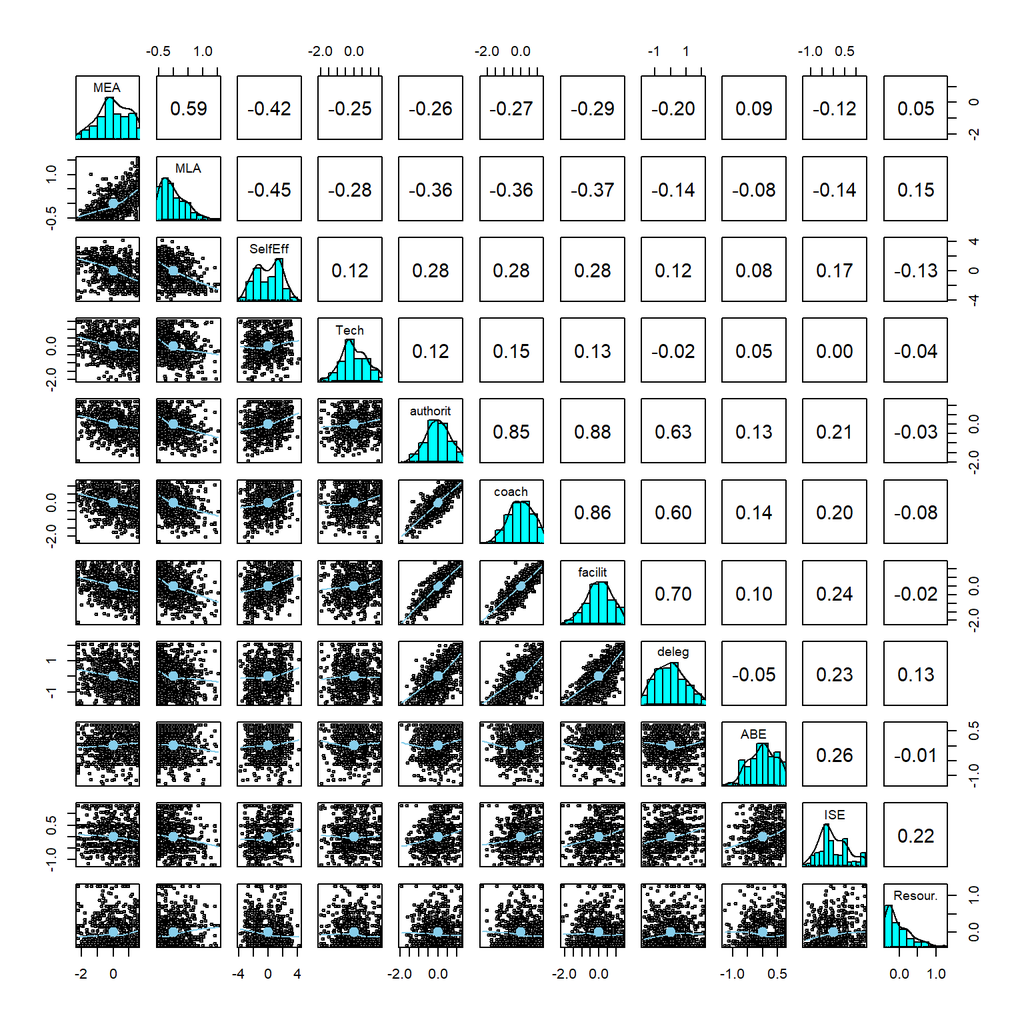

```r
var.name <-c( "Anxiety.mea.cfa", "Anxiety.mla.cfa", "SelfEfficacy.cfa", "Technology.cfa",
                "authority.cfa", "coach.cfa", "facilitator.cfa", "delegator.cfa", "behavorialEngage.cfa",
              "socialEngage.cfa", "Resource.cfa")
all.composite.scores <- final.anxiety.dat[, var.name]
###
cor.plot <- final.anxiety.dat[, var.name]
names(cor.plot) <- c( "MEA", "MLA", "SelfEff", "Tech",
              "authorit", "coach", "facilit", "deleg", "ABE",
              "ISE", "Resour.")
###
pairs.panels(cor.plot , pch = 21, col = "skyblue", cex = 0.5, cex.cor = 1.2, alpha = 0.7, bg = "gray", cex.labels = 0.9)
```

```r
# Calculate correlation matrix
cor_matrix <- cor(all.composite.scores, use = "complete.obs")

# Convert to long format using melt
cor_long <- melt(cor_matrix)
names(cor_long) <- c("x", "y", "r")

# Remove self-correlations and upper triangle if desired
cor_long <- cor_long[cor_long$x != cor_long$y, ]

# Create interactive heatmap
plot_ly(cor_long, x = ~x, y = ~y, z = ~r, type = "heatmap",
        colorscale = "RdBu", zmin = -1, zmax = 1,
        hoverinfo = "text",
        text = ~paste("X:", x, "<br>Y:", y, "<br>r =", round(r, 3))) %>%
  layout(title = "Correlation Matrix",
         xaxis = list(title = ""),
         yaxis = list(title = ""),
         margin = list(l = 100, r = 50, b = 100, t = 50))
```

[interactive chart not shown]

The figure above shows that all perceived teaching strategies are negatively correlated with both types of anxiety. In addition, students with high levels of self-efficacy tend to have low levels of math anxiety. Furthermore, the composite score for technology use is negatively correlated with both learning and evaluation anxiety, implying that technology can help reduce math anxiety. Conversely, we also see that students who use more learning resources tend to have higher learning anxiety.

In the next few subsections, we analyze relationships between the scales in this survey and compare our results with those in the existing literature.

## 8.1 Interrelationship Between Evaluation and Learning Anxieties

A positive correlation was found between mathematics evaluation anxiety and mathematics learning anxiety, which is consistent with previous research.

Mathematics learning anxiety is often the broader, foundational issue, stemming from negative experiences and beliefs about one’s own mathematical ability. Mathematics test anxiety is a more specific, situational manifestation of this broader anxiety, triggered by the evaluative pressure of exams.

The primary relationship is cyclical: learning anxiety fosters test anxiety, and a negative test experience reinforces learning anxiety. Gierl and Bisanz (1995) highlighted this cyclical nature. They suggested that early negative experiences with math (leading to learning anxiety) set the stage for later test anxiety. Conversely, a single traumatic test experience (e.g., a disastrous final exam) can generalize to a long-lasting, pervasive anxiety toward all math-related activities, solidifying learning anxiety. Zakaria et al. (2012) found a significant positive correlation between general mathematics anxiety and test anxiety. Students who are already anxious in daily math classes are primed for heightened anxiety when the stakes are raised in a test.

Both anxieties often stem from common roots, which explains their high positive inter-relationship.

- **Negative Past Experiences**: Repeated failure or humiliation in math classes during K-12 education is a powerful predictor for both types of anxiety in college (Maloney & Beilock, 2012).
- **Societal and Environmental Factors**: Cultural stereotypes (e.g., “math is for boys,” “some people just aren’t math people”) and teacher anxiety can be transmitted to students, fostering a general sense of apprehension toward the subject.
- **Fixed Mindset**: The work of Carol Dweck (2006) on mindset is highly relevant. Students with a “fixed mindset” (the belief that math ability is an innate, unchangeable trait) are more vulnerable to both learning and test anxiety. Any struggle is seen as evidence of a lack of ability, causing them to avoid challenging learning and to crumble under the evaluative pressure of tests.

## 8.2 Student Perceived Teaching Strategies

- **Instructor Versatility and Strategic Blending**: A single lesson might begin with a brief lecture to introduce a concept, use a demonstrative example, and then engage students in a cooperative problem-solving activity to apply the concept inductively. Students perceive this blending, leading to positive correlations among the strategies they observe.
- **Student Recognition of a Coherent Learning Cycle**: Students may perceive that different strategies serve different, but interconnected, purposes in their learning journey. For instance, a repetitive practice session might logically follow a deductive explanation of a formula to build fluency, and an integrative project might cap a unit to show real-world application. When these strategies are sequenced effectively, students see them as parts of a whole, coherent experience, leading to positive ratings across the board (Boaler, 2016).
- **The Halo Effect of Pedagogical Richness**: A classroom environment rich with varied pedagogical approaches is often more engaging. The positive affect generated by one engaging strategy (e.g., a fun cooperative activity) can create a “halo effect,” leading students to rate all the strategies used in that positive context more highly, even the more traditional ones like lecture-type instruction (Hattie, 2012).

However, these correlations can also be inflated by generalized student attitudes rather than precise reflections of discrete teaching acts. For example, the correlations might not reflect the actual frequency of use but a generalized student perception of their instructor. A student who holds a positive overall view of the teacher might rate all teaching strategies highly, regardless of how effectively each was individually deployed. This is a common form of response bias in student evaluations (Spooren et al., 2013).

The correlation might also be confounded due to lack of discriminant validity in perception. For ewxample, students, especially those without pedagogical training, may not finely discriminate between the nuanced definitions of each strategy. They might broadly perceive “the teacher explains things clearly,” which could lead them to rate deductive, demonstrative, and integrative strategies similarly because they all contribute to that overarching feeling of clarity.

## 8.3 Lowess Regression Between Anxiety and Teaching Strategies

First, we add some moderation analyses to support the visual presentation in the Figure 1.

- **Create the wide dataframe exactly as you described**

```r
###
LoessData <- finalDat
##
#set.seed(42)
n <- 693
# Create the wide dataframe exactly as you described
df_wide <- data.frame(
  Subject = 1:n,
  Gender = LoessData$sex,
  MLA = LoessData$Anxiety.mla.cfa,
  MEA = LoessData$Anxiety.mea.cfa,
  ###
  authority = LoessData$authority.cfa,
  coach = LoessData$coach.cfa,
  facilitator = LoessData$facilitator.cfa,
  delegator= LoessData$delegator.cfa
)
```

- **DATA PREPARATION AND RESHAPING**

```r
# A. Standardize the 4 teaching strategies (Z-scores)
# This is crucial because they are FA composite scores and might be on different scales.
# It allows you to compare them on the same Y-axis.
df_wide <- df_wide %>%
  mutate(across(authority:delegator, ~ scale(.)[,1], .names = "{.col}_z"))

# B. Reshape from Wide to Long format
df_long <- df_wide %>%
  pivot_longer(
    cols = ends_with("_z"), # Select the standardized teaching strategies
    names_to = "TeachingStyle",
    values_to = "TeachingIndex"
  ) %>%
  mutate(
    # Clean up the teaching style names (remove "_z")
    TeachingStyle = str_remove(TeachingStyle, "_z"),

    # Reshape the Anxiety variables (MLA and MEA) into a single column
    # We do this by creating two separate long datasets and binding them,
    # or by using pivot_longer on the anxiety columns.
    AnxietyType = "Placeholder" # We will fix this in the next step
  )

# To properly reshape the two anxiety variables (MLA, MEA) into one column:
df_long <- df_wide %>%
  pivot_longer(
    cols = c(MLA, MEA),
    names_to = "AnxietyType",
    values_to = "MathAnxiety"
  ) %>%
  # Now pivot the teaching strategies
  pivot_longer(
    cols = ends_with("_z"),
    names_to = "TeachingStyle",
    values_to = "TeachingIndex"
  ) %>%
  mutate(
    TeachingStyle = str_remove(TeachingStyle, "_z"),
    # Center the Anxiety variable (recommended for quadratic terms)
    MathAnxiety_c = scale(MathAnxiety, center = TRUE, scale = FALSE)[,1]
  )

# Check the structure of the long data
# It should have n * 2 (anxiety types) * 4 (styles) = 696 * 8 = 5544 rows
# glimpse(df_long)
```

- **Fit the Mixed-Effects Model**

Now we fit the model. Note that TeachingStyle is a within-subject factor (each person rated all 4 styles), so we include a random intercept for Subject.

Note on convergence: A 4-way interaction with 4 levels of TeachingStyle is very complex. If this model fails to converge, see the troubleshooting note below.

```r
# Fit the model
# Fixed effects: Anxiety (linear + quadratic) * AnxietyType * Gender * TeachingStyle
model <- lmer(TeachingIndex ~ (MathAnxiety_c + I(MathAnxiety_c^2)) * AnxietyType * Gender * TeachingStyle + (1 | Subject),  data = df_long)
anova(model)
```

```
Type III Analysis of Variance Table with Satterthwaite's method
                                                     Sum Sq Mean Sq NumDF
MathAnxiety_c                                        1.7014  1.7014     1
I(MathAnxiety_c^2)                                   0.0709  0.0709     1
AnxietyType                                          0.0422  0.0422     1
Gender                                               0.1781  0.1781     1
TeachingStyle                                        1.2147  0.4049     3
MathAnxiety_c:AnxietyType                            0.6754  0.6754     1
I(MathAnxiety_c^2):AnxietyType                       0.1186  0.1186     1
MathAnxiety_c:Gender                                 0.0000  0.0000     1
I(MathAnxiety_c^2):Gender                            0.0003  0.0003     1
AnxietyType:Gender                                   0.0090  0.0090     1
MathAnxiety_c:TeachingStyle                         25.4361  8.4787     3
I(MathAnxiety_c^2):TeachingStyle                     1.3553  0.4518     3
AnxietyType:TeachingStyle                            0.2248  0.0749     3
Gender:TeachingStyle                                 2.1711  0.7237     3
MathAnxiety_c:AnxietyType:Gender                     0.0000  0.0000     1
I(MathAnxiety_c^2):AnxietyType:Gender                0.0001  0.0001     1
MathAnxiety_c:AnxietyType:TeachingStyle             14.4802  4.8267     3
I(MathAnxiety_c^2):AnxietyType:TeachingStyle         0.9595  0.3198     3
MathAnxiety_c:Gender:TeachingStyle                   6.5494  2.1831     3
I(MathAnxiety_c^2):Gender:TeachingStyle              2.1959  0.7320     3
AnxietyType:Gender:TeachingStyle                     0.7427  0.2476     3
MathAnxiety_c:AnxietyType:Gender:TeachingStyle       3.2341  1.0780     3
I(MathAnxiety_c^2):AnxietyType:Gender:TeachingStyle  2.4138  0.8046     3
                                                     DenDF F value    Pr(>F)
MathAnxiety_c                                       5464.6  8.3036  0.003972
I(MathAnxiety_c^2)                                  5229.4  0.3461  0.556372
AnxietyType                                         4899.6  0.2060  0.649913
Gender                                               776.0  0.8694  0.351408
TeachingStyle                                       4789.8  1.9761  0.115306
MathAnxiety_c:AnxietyType                           5205.7  3.2964  0.069489
I(MathAnxiety_c^2):AnxietyType                      5128.9  0.5788  0.446823
MathAnxiety_c:Gender                                5464.6  0.0001  0.993225
I(MathAnxiety_c^2):Gender                           5229.4  0.0016  0.968179
AnxietyType:Gender                                  4899.6  0.0437  0.834437
MathAnxiety_c:TeachingStyle                         4789.8 41.3788 < 2.2e-16
I(MathAnxiety_c^2):TeachingStyle                    4789.8  2.2047  0.085410
AnxietyType:TeachingStyle                           4789.8  0.3657  0.777787
Gender:TeachingStyle                                4789.8  3.5319  0.014195
```

[output cut: 20 more lines]

```
MathAnxiety_c:TeachingStyle                         ***
I(MathAnxiety_c^2):TeachingStyle                    .
AnxietyType:TeachingStyle
Gender:TeachingStyle                                *
MathAnxiety_c:AnxietyType:Gender
I(MathAnxiety_c^2):AnxietyType:Gender
MathAnxiety_c:AnxietyType:TeachingStyle             ***
I(MathAnxiety_c^2):AnxietyType:TeachingStyle
MathAnxiety_c:Gender:TeachingStyle                  ***
I(MathAnxiety_c^2):Gender:TeachingStyle             *
AnxietyType:Gender:TeachingStyle
MathAnxiety_c:AnxietyType:Gender:TeachingStyle      **
I(MathAnxiety_c^2):AnxietyType:Gender:TeachingStyle **
---
Signif. codes:  0 '***' 0.001 '**' 0.01 '*' 0.05 '.' 0.1 ' ' 1
```

- **Answer Specific Research Questions**

**Q1 & Q2: Does anxiety predict the index? Does the slope differ between MEA and MLA?**

Because we have a 4-way interaction, the “main effect” of anxiety is conditional on Gender and TeachingStyle. We should test the simple slopes of anxiety for MEA vs MLA, averaged over the other factors.

```r
# Test the linear trend of Anxiety for MEA vs MLA
emm_anxiety_type <- emtrends(model, ~ AnxietyType, var = "MathAnxiety_c")
print(emm_anxiety_type)
```

```
 AnxietyType MathAnxiety_c.trend     SE  df asymp.LCL asymp.UCL
 MEA                     -0.0415 0.0168 Inf   -0.0743  -0.00858
 MLA                     -0.1108 0.0429 Inf   -0.1949  -0.02674

Results are averaged over the levels of: Gender, TeachingStyle
Degrees-of-freedom method: asymptotic
Confidence level used: 0.95
```

- **GAM() assessing association between MEA/MLA and individual teaching strategies**

```r
reg.data <- finalDat
reg.name <- c("ID", "sex", "race", "class", "major",  "math.level",  "modality", "MEA",  "MLA", "SelfEfficacy", "Technology", "authority",  "coach",  "facilitator", "delegator", "teacherCtrd", "studentCtrd", "ABE", "ISE", "Resource")
colnames(reg.data) = reg.name
```

```r
gam.m00 <- gam(MEA ~  sex+     s(authority, bs = "cs", k =4) +
                          s(coach, bs = "cs", k =4) +
                          s(facilitator, bs = "cs", k = 4) +
                          s(delegator, bs = "cs", k=4),
              data = reg.data,
              select = TRUE,      # Enable automatic term selection
              method = "REML")    # Use REML for smoothness selection
#gam.check(gam.m00)
```

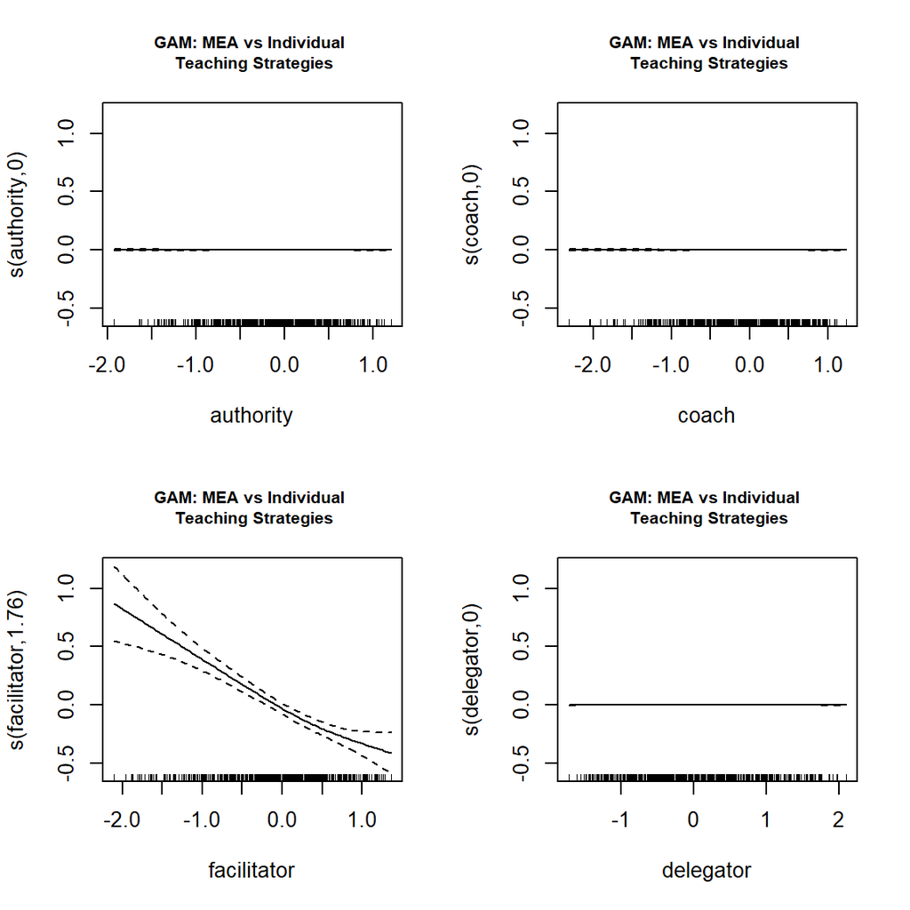

```r
par(mfrow= c(2,2))
plot(gam.m00,  main = "GAM: MEA vs Individual \n Teaching Strategies",
     cex.main = 0.8)
```

```r
summary(gam.m00)
```

```
Family: gaussian
Link function: identity

Formula:
MEA ~ sex + s(authority, bs = "cs", k = 4) + s(coach, bs = "cs",
    k = 4) + s(facilitator, bs = "cs", k = 4) + s(delegator,
    bs = "cs", k = 4)

Parametric coefficients:
            Estimate Std. Error t value Pr(>|t|)
(Intercept)  0.14899    0.04220   3.531 0.000442 ***
sexmale     -0.46548    0.07459  -6.241 7.62e-10 ***
---
Signif. codes:  0 '***' 0.001 '**' 0.01 '*' 0.05 '.' 0.1 ' ' 1

Approximate significance of smooth terms:
                     edf Ref.df     F p-value
s(authority)   0.0002530      3  0.00   0.732
s(coach)       0.0004227      3  0.00   0.481
s(facilitator) 1.7632805      3 21.69  <2e-16 ***
s(delegator)   0.0002654      3  0.00   0.974
---
Signif. codes:  0 '***' 0.001 '**' 0.01 '*' 0.05 '.' 0.1 ' ' 1

R-sq.(adj) =  0.134   Deviance explained = 13.7%
-REML = 928.07  Scale est. = 0.83843   n = 693
```

```r
gam.m01 <- gam(MLA ~       s(authority, bs = "cs", k =4) +
                          s(coach, bs = "cs", k =4) +
                          s(facilitator, bs = "cs", k = 8) +
                          s(delegator, bs = "cs", k=8),
              data = reg.data,
              select = TRUE,      # Enable automatic term selection
              method = "REML")    # Use REML for smoothness selection
#gam.check(gam.m01)
```

[figure not shown]

```r
par(mfrow= c(2,2))
plot(gam.m01,  main = "GAM: MEA vs Individual \n Teaching Strategies",
     cex.main = 0.8)
```

```r
par(mfrow= c(2,2))
summary(gam.m01)
```

```
Family: gaussian
Link function: identity

Formula:
MLA ~ s(authority, bs = "cs", k = 4) + s(coach, bs = "cs", k = 4) +
    s(facilitator, bs = "cs", k = 8) + s(delegator, bs = "cs",
    k = 8)

Parametric coefficients:
             Estimate Std. Error t value Pr(>|t|)
(Intercept) -0.001708   0.014862  -0.115    0.909

Approximate significance of smooth terms:
                  edf Ref.df     F  p-value
s(authority)   0.8302      3 0.661  0.08418 .
s(coach)       2.1998      3 3.653  0.00162 **
s(facilitator) 1.3824      7 2.315 1.85e-05 ***
s(delegator)   1.8305      7 2.945 5.74e-06 ***
---
Signif. codes:  0 '***' 0.001 '**' 0.01 '*' 0.05 '.' 0.1 ' ' 1

R-sq.(adj) =  0.178   Deviance explained = 18.5%
-REML = 344.28  Scale est. = 0.15306   n = 693
```

**Q3 & Q4: Does the slope differ by Gender? Is there a three-way interaction?**

The `anova(model)` output above will tell you if `MathAnxiety_c:Gender` (Q3) and `MathAnxiety_c:AnxietyType:Gender` (Q4) are significant. You can also probe this directly:

```r
# Test the 3-way interaction (Anxiety x Type x Gender) averaged over TeachingStyle
emm_3way <- emtrends(model, ~ AnxietyType | Gender, var = "MathAnxiety_c")
print(emm_3way)
```

```
Gender = female:
 AnxietyType MathAnxiety_c.trend     SE  df asymp.LCL asymp.UCL
 MEA                     -0.0414 0.0191 Inf   -0.0789  -0.00394
 MLA                     -0.1113 0.0513 Inf   -0.2118  -0.01080

Gender = male:
 AnxietyType MathAnxiety_c.trend     SE  df asymp.LCL asymp.UCL
 MEA                     -0.0415 0.0276 Inf   -0.0955   0.01255
 MLA                     -0.1104 0.0688 Inf   -0.2452   0.02448

Results are averaged over the levels of: TeachingStyle
Degrees-of-freedom method: asymptotic
Confidence level used: 0.95
```

```r
# Pairwise comparison to see if MEA slope differs from MLA slope for each Gender
pairs(emm_3way, simple = "each")
```

```
$`simple contrasts for AnxietyType`
Gender = female:
 contrast  estimate     SE  df z.ratio p.value
 MEA - MLA   0.0699 0.0444 Inf   1.574  0.1155

Gender = male:
 contrast  estimate     SE  df z.ratio p.value
 MEA - MLA   0.0689 0.0621 Inf   1.109  0.2674

Results are averaged over the levels of: TeachingStyle
Degrees-of-freedom method: asymptotic

$`simple contrasts for Gender`
AnxietyType = MEA:
 contrast       estimate     SE  df z.ratio p.value
 female - male  6.45e-05 0.0335 Inf   0.002  0.9985

AnxietyType = MLA:
 contrast       estimate     SE  df z.ratio p.value
 female - male -9.44e-04 0.0858 Inf  -0.011  0.9912

Results are averaged over the levels of: TeachingStyle
Degrees-of-freedom method: asymptotic
```

**Q5: Does discriminability collapse more rapidly in MLA than MEA?**

- **Effect Sizes and Confidence Intervals**

```r
eta_squared(model, partial = TRUE)
```

```
# Effect Size for ANOVA (Type III)

Parameter                                           | Eta2 (partial) |       95% CI
-----------------------------------------------------------------------------------
MathAnxiety_c                                       |       1.52e-03 | [0.00, 1.00]
I(MathAnxiety_c^2)                                  |       6.62e-05 | [0.00, 1.00]
AnxietyType                                         |       4.20e-05 | [0.00, 1.00]
Gender                                              |       1.12e-03 | [0.00, 1.00]
TeachingStyle                                       |       1.24e-03 | [0.00, 1.00]
MathAnxiety_c:AnxietyType                           |       6.33e-04 | [0.00, 1.00]
I(MathAnxiety_c^2):AnxietyType                      |       1.13e-04 | [0.00, 1.00]
MathAnxiety_c:Gender                                |       1.32e-08 | [0.00, 1.00]
I(MathAnxiety_c^2):Gender                           |       3.04e-07 | [0.00, 1.00]
AnxietyType:Gender                                  |       8.92e-06 | [0.00, 1.00]
MathAnxiety_c:TeachingStyle                         |           0.03 | [0.02, 1.00]
I(MathAnxiety_c^2):TeachingStyle                    |       1.38e-03 | [0.00, 1.00]
AnxietyType:TeachingStyle                           |       2.29e-04 | [0.00, 1.00]
Gender:TeachingStyle                                |       2.21e-03 | [0.00, 1.00]
MathAnxiety_c:AnxietyType:Gender                    |       3.40e-08 | [0.00, 1.00]
I(MathAnxiety_c^2):AnxietyType:Gender               |       1.40e-07 | [0.00, 1.00]
MathAnxiety_c:AnxietyType:TeachingStyle             |           0.01 | [0.01, 1.00]
I(MathAnxiety_c^2):AnxietyType:TeachingStyle        |       9.77e-04 | [0.00, 1.00]
MathAnxiety_c:Gender:TeachingStyle                  |       6.63e-03 | [0.00, 1.00]
I(MathAnxiety_c^2):Gender:TeachingStyle             |       2.23e-03 | [0.00, 1.00]
AnxietyType:Gender:TeachingStyle                    |       7.56e-04 | [0.00, 1.00]
MathAnxiety_c:AnxietyType:Gender:TeachingStyle      |       3.28e-03 | [0.00, 1.00]
I(MathAnxiety_c^2):AnxietyType:Gender:TeachingStyle |       2.45e-03 | [0.00, 1.00]

- One-sided CIs: upper bound fixed at [1.00].
```

```r
model_parameters(
model,
ci = 0.95,
effects = "fixed"
)
```

```
# Fixed Effects

Parameter
-----------------------------------------------------------------------------------
(Intercept)
MathAnxiety c
MathAnxiety c^2
AnxietyType [MLA]
Gender [male]
TeachingStyle [coach]
TeachingStyle [delegator]
TeachingStyle [facilitator]
MathAnxiety c × AnxietyType [MLA]
MathAnxiety c^2 × AnxietyType [MLA]
MathAnxiety c × Gender [male]
MathAnxiety c^2 × Gender [male]
AnxietyType [MLA] × Gender [male]
MathAnxiety c × TeachingStyle [coach]
MathAnxiety c × TeachingStyle [delegator]
MathAnxiety c × TeachingStyle [facilitator]
MathAnxiety c^2 × TeachingStyle [coach]
MathAnxiety c^2 × TeachingStyle [delegator]
MathAnxiety c^2 × TeachingStyle [facilitator]
AnxietyType [MLA] × TeachingStyle [coach]
AnxietyType [MLA] × TeachingStyle [delegator]
AnxietyType [MLA] × TeachingStyle [facilitator]
Gender [male] × TeachingStyle [coach]
Gender [male] × TeachingStyle [delegator]
Gender [male] × TeachingStyle [facilitator]
(MathAnxiety c × AnxietyType [MLA]) × Gender [male]
(MathAnxiety c^2 × AnxietyType [MLA]) × Gender [male]
(MathAnxiety c × AnxietyType [MLA]) × TeachingStyle [coach]
(MathAnxiety c × AnxietyType [MLA]) × TeachingStyle [delegator]
(MathAnxiety c × AnxietyType [MLA]) × TeachingStyle [facilitator]
(MathAnxiety c^2 × AnxietyType [MLA]) × TeachingStyle [coach]
(MathAnxiety c^2 × AnxietyType [MLA]) × TeachingStyle [delegator]
(MathAnxiety c^2 × AnxietyType [MLA]) × TeachingStyle [facilitator]
(MathAnxiety c × Gender [male]) × TeachingStyle [coach]
(MathAnxiety c × Gender [male]) × TeachingStyle [delegator]
(MathAnxiety c × Gender [male]) × TeachingStyle [facilitator]
```

[output cut: 48 more lines]

```
       0.08 | 0.06 | [-0.04,  0.19] |      1.34 | 0.179
       0.13 | 0.06 | [ 0.01,  0.24] |      2.22 | 0.026
  -6.76e-03 | 0.06 | [-0.12,  0.10] |     -0.12 | 0.905
  -6.54e-03 | 0.05 | [-0.10,  0.09] |     -0.14 | 0.890
   7.67e-03 | 0.05 | [-0.08,  0.10] |      0.16 | 0.871
      -0.04 | 0.05 | [-0.13,  0.05] |     -0.86 | 0.392
       0.05 | 0.10 | [-0.14,  0.25] |      0.53 | 0.593
       0.18 | 0.10 | [-0.02,  0.37] |      1.78 | 0.075
       0.03 | 0.10 | [-0.16,  0.23] |      0.35 | 0.729
       0.25 | 0.16 | [-0.06,  0.57] |      1.59 | 0.111
       0.63 | 0.16 | [ 0.32,  0.94] |      3.95 | < .001
       0.29 | 0.16 | [-0.02,  0.61] |      1.84 | 0.066
      -0.30 | 0.23 | [-0.76,  0.15] |     -1.31 | 0.191
      -0.76 | 0.23 | [-1.22, -0.31] |     -3.30 | < .001
      -0.19 | 0.23 | [-0.65,  0.26] |     -0.83 | 0.407
```

- **Visualizing the Results to Match the Figure**

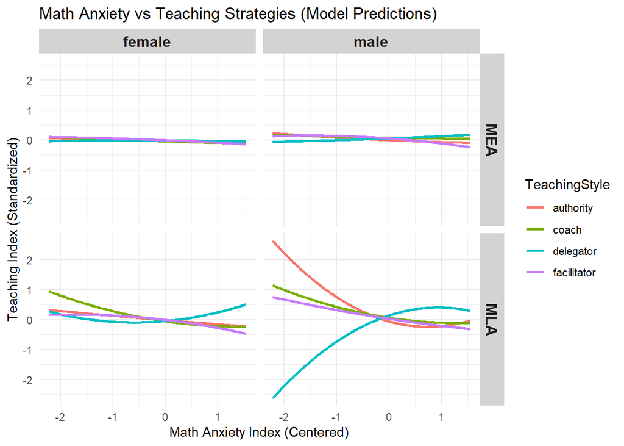

```r
# Generate predicted values for the plot
preds <- ggpredict(model, terms = c("MathAnxiety_c [all]", "TeachingStyle", "AnxietyType", "Gender"))
##
## Plot using ggplot2
ggplot(preds, aes(x = x, y = predicted, color = group)) +
  geom_line(linewidth = 1) + # Note: 'size' is deprecated for lines, use 'linewidth'
  # Use the standardized column names from ggpredict: facet and panel
  facet_grid(facet ~ panel) +
  labs(
    title = "Math Anxiety vs Teaching Strategies (Model Predictions)",
    x = "Math Anxiety Index (Centered)",
    y = "Teaching Index (Standardized)",
    color = "TeachingStyle"
  ) +
  theme_minimal() +
  theme(
    legend.position = "right",
    strip.text = element_text(size = 12, face = "bold"),
    strip.background = element_rect(fill = "lightgrey", color = NA)
  )
```

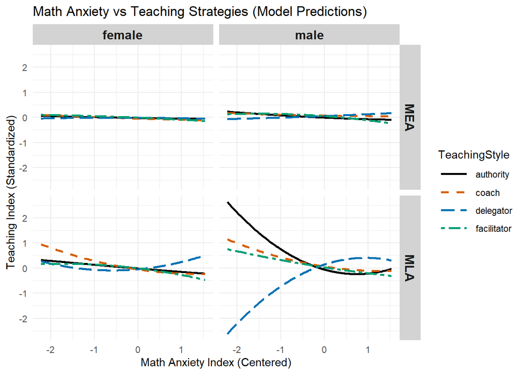

```r
# Generate predicted values for the plot
preds <- ggpredict(model, terms = c("MathAnxiety_c [all]", "TeachingStyle", "AnxietyType", "Gender"))

# 7 colorblind-safe colors (Okabe-Ito palette + black)
# Reference: Wong, B. (2011). Points of view: Color blindness. Nature Methods, 8, 441.
cb_safe_colors <- c(
  "darkred",
  "#009E73",  # bluish green
  "orange",
  "#0072B2"  # blue
)

high_contrast_colors <- c(
  "#000000",  # black          — highest contrast on white
  "#D55E00",  # vermillion     — strong warm, CVD-safe
  "#0072B2",  # strong blue    — CVD-safe, high contrast
  "#009E73",  # bluish green   — CVD-safe, high contrast
  "#CC79A7"  # reddish purple — CVD-safe
)
# 7 distinguishable line types (6 built-in + 1 custom hex pattern)
cb_safe_linetypes <- c(
  "solid",       # 1
  "dashed",      # 2
  "longdash",      # 3
  "twodash"    # 4
)

# Plot using ggplot2
fig01 <-ggplot(preds, aes(x = x, y = predicted, color = group, linetype = group)) +
  geom_line(linewidth = 1) +
  scale_color_manual(values = high_contrast_colors) +
  scale_linetype_manual(values = cb_safe_linetypes) +
  # Use the standardized column names from ggpredict: facet and panel
  facet_grid(facet ~ panel) +
  labs(
    title = "Math Anxiety vs Teaching Strategies (Model Predictions)",
    x = "Math Anxiety Index (Centered)",
    y = "Teaching Index (Standardized)",
    color = "TeachingStyle",
    linetype = "TeachingStyle"
  ) +
  theme_minimal() +
  theme(
    legend.position = "right",
    strip.text = element_text(size = 12, face = "bold"),
    strip.background = element_rect(fill = "lightgrey", color = NA),
    legend.key.width = unit(1.1, "cm")  # wider keys so line types are visible
  )
fig01
```

```r
ggsave(
  filename = "C:\\Users\\75CPENG\\OneDrive - West Chester University of PA\\Desktop\\cpeng\\WCU-Research\\2026\\AnxietyPapers\\ThreePapers\\figure01.pdf",
  plot     = fig01,        # the ggplot object
  width    = 9,            # inches
  height   = 7,            # inches
  units    = "in",
  dpi      = 300,          # for rasterized elements (points, etc.)
  device   = "pdf"
)
```

```r
eta_squared(model, partial = TRUE, ci = 0.95)
```

```
# Effect Size for ANOVA (Type III)

Parameter                                           | Eta2 (partial) |       95% CI
-----------------------------------------------------------------------------------
MathAnxiety_c                                       |       1.52e-03 | [0.00, 1.00]
I(MathAnxiety_c^2)                                  |       6.62e-05 | [0.00, 1.00]
AnxietyType                                         |       4.20e-05 | [0.00, 1.00]
Gender                                              |       1.12e-03 | [0.00, 1.00]
TeachingStyle                                       |       1.24e-03 | [0.00, 1.00]
MathAnxiety_c:AnxietyType                           |       6.33e-04 | [0.00, 1.00]
I(MathAnxiety_c^2):AnxietyType                      |       1.13e-04 | [0.00, 1.00]
MathAnxiety_c:Gender                                |       1.32e-08 | [0.00, 1.00]
I(MathAnxiety_c^2):Gender                           |       3.04e-07 | [0.00, 1.00]
AnxietyType:Gender                                  |       8.92e-06 | [0.00, 1.00]
MathAnxiety_c:TeachingStyle                         |           0.03 | [0.02, 1.00]
I(MathAnxiety_c^2):TeachingStyle                    |       1.38e-03 | [0.00, 1.00]
AnxietyType:TeachingStyle                           |       2.29e-04 | [0.00, 1.00]
Gender:TeachingStyle                                |       2.21e-03 | [0.00, 1.00]
MathAnxiety_c:AnxietyType:Gender                    |       3.40e-08 | [0.00, 1.00]
I(MathAnxiety_c^2):AnxietyType:Gender               |       1.40e-07 | [0.00, 1.00]
MathAnxiety_c:AnxietyType:TeachingStyle             |           0.01 | [0.01, 1.00]
I(MathAnxiety_c^2):AnxietyType:TeachingStyle        |       9.77e-04 | [0.00, 1.00]
MathAnxiety_c:Gender:TeachingStyle                  |       6.63e-03 | [0.00, 1.00]
I(MathAnxiety_c^2):Gender:TeachingStyle             |       2.23e-03 | [0.00, 1.00]
AnxietyType:Gender:TeachingStyle                    |       7.56e-04 | [0.00, 1.00]
MathAnxiety_c:AnxietyType:Gender:TeachingStyle      |       3.28e-03 | [0.00, 1.00]
I(MathAnxiety_c^2):AnxietyType:Gender:TeachingStyle |       2.45e-03 | [0.00, 1.00]

- One-sided CIs: upper bound fixed at [1.00].
```

```r
parameters::model_parameters(model, ci = 0.95)
```

```
# Fixed Effects

Parameter
-----------------------------------------------------------------------------------
(Intercept)
MathAnxiety c
MathAnxiety c^2
AnxietyType [MLA]
Gender [male]
TeachingStyle [coach]
TeachingStyle [delegator]
TeachingStyle [facilitator]
MathAnxiety c × AnxietyType [MLA]
MathAnxiety c^2 × AnxietyType [MLA]
MathAnxiety c × Gender [male]
MathAnxiety c^2 × Gender [male]
AnxietyType [MLA] × Gender [male]
MathAnxiety c × TeachingStyle [coach]
MathAnxiety c × TeachingStyle [delegator]
MathAnxiety c × TeachingStyle [facilitator]
MathAnxiety c^2 × TeachingStyle [coach]
MathAnxiety c^2 × TeachingStyle [delegator]
MathAnxiety c^2 × TeachingStyle [facilitator]
AnxietyType [MLA] × TeachingStyle [coach]
AnxietyType [MLA] × TeachingStyle [delegator]
AnxietyType [MLA] × TeachingStyle [facilitator]
Gender [male] × TeachingStyle [coach]
Gender [male] × TeachingStyle [delegator]
Gender [male] × TeachingStyle [facilitator]
(MathAnxiety c × AnxietyType [MLA]) × Gender [male]
(MathAnxiety c^2 × AnxietyType [MLA]) × Gender [male]
(MathAnxiety c × AnxietyType [MLA]) × TeachingStyle [coach]
(MathAnxiety c × AnxietyType [MLA]) × TeachingStyle [delegator]
(MathAnxiety c × AnxietyType [MLA]) × TeachingStyle [facilitator]
(MathAnxiety c^2 × AnxietyType [MLA]) × TeachingStyle [coach]
(MathAnxiety c^2 × AnxietyType [MLA]) × TeachingStyle [delegator]
(MathAnxiety c^2 × AnxietyType [MLA]) × TeachingStyle [facilitator]
(MathAnxiety c × Gender [male]) × TeachingStyle [coach]
(MathAnxiety c × Gender [male]) × TeachingStyle [delegator]
(MathAnxiety c × Gender [male]) × TeachingStyle [facilitator]
```

[output cut: 55 more lines]

```
       0.18 | 0.10 | [-0.02,  0.37] |      1.78 | 0.075
       0.03 | 0.10 | [-0.16,  0.23] |      0.35 | 0.729
       0.25 | 0.16 | [-0.06,  0.57] |      1.59 | 0.111
       0.63 | 0.16 | [ 0.32,  0.94] |      3.95 | < .001
       0.29 | 0.16 | [-0.02,  0.61] |      1.84 | 0.066
      -0.30 | 0.23 | [-0.76,  0.15] |     -1.31 | 0.191
      -0.76 | 0.23 | [-1.22, -0.31] |     -3.30 | < .001
      -0.19 | 0.23 | [-0.65,  0.26] |     -0.83 | 0.407

# Random Effects

Parameter               | Coefficient
-------------------------------------
SD (Intercept: Subject) |        0.88
SD (Residual)           |        0.45
```

- **Test Anxiety**

```r
# define a long table for group plots
## Test Anxiety
mea.tech.by.gender <- data.frame(
  anxety.index = rep(finalDat$Anxiety.mea.cfa, 4),  # These are CFA scores!!!
  gender.anx.type = paste0(rep(finalDat$sex, 4), " & mea"),
  teach.index = c(finalDat$authority.cfa, finalDat$coach.cfa,
                  finalDat$facilitator.cfa, finalDat$delegator.cfa),
  TeachingStyle = rep(c("authority", "coach", "facilitator", "delegator"), each = 693)
)
names(mea.tech.by.gender) <- c("anxety.index", "gender.anx.type", "teach.index", "TeachingStrategy")
mea.tech.by.gender <- na.omit(mea.tech.by.gender)

## Learning Anxiety   4019
mla.tech.by.gender <- data.frame(
  anxety.index = rep(finalDat$Anxiety.mla.cfa, 4),
  gender.anx.type = paste0(rep(finalDat$sex, 4), " & mla"),
  teach.index = c(finalDat$authority.cfa, finalDat$coach.cfa,
                  finalDat$facilitator.cfa, finalDat$delegator.cfa),
  TeachingStyle = rep(c("authority", "coach", "facilitator", "delegator"), each = 693)
)
names(mla.tech.by.gender) <- c("anxety.index", "gender.anx.type", "teach.index", "TeachingStrategy")
mla.tech.by.gender <- na.omit(mla.tech.by.gender)

colors_7 <-  c("#E69F00", "#56B4E9", "#009E73", "#F0E442",
                      "#0072B2", "#D55E00", "#CC79A7")
distinct_linetypes <- c("solid", "dashed", "dotted", "dotdash",
                        "longdash", "twodash", "22")
## Stacking
anxiety.sex.teach <- na.omit(rbind(mla.tech.by.gender, mea.tech.by.gender))
```

- **Create ggplot with facets**

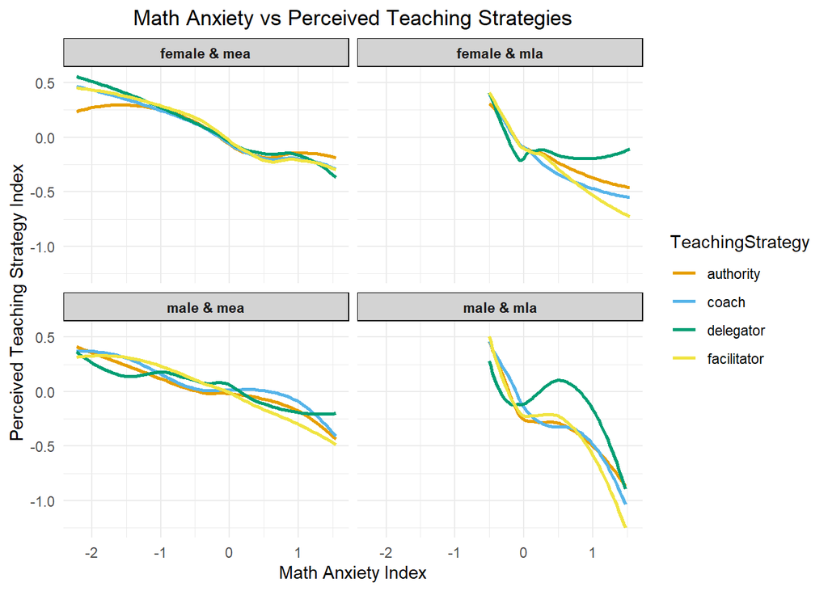

```r
# Create ggplot with facets
gg <- ggplot(anxiety.sex.teach, aes(x = anxety.index, y = teach.index, color = TeachingStrategy, group = TeachingStrategy)) +
  #geom_point(alpha = 0.5, size = 1.5) +
  geom_smooth(method = "loess", span = 0.75, se = FALSE, size = 1) +
  facet_wrap(~ gender.anx.type, ncol = 2, nrow = 2) +
  scale_color_manual(values = colors_7) +
  scale_linetype_manual(values = distinct_linetypes) +
  #scale_color_viridis_d(option = "plasma") +
  labs(title = "Math Anxiety vs Perceived Teaching Strategies",
       x = "Math Anxiety Index",
       y = "Perceived Teaching Strategy Index") +
  theme_minimal() +
  theme(
    strip.background = element_rect(fill = "lightgray"),
    strip.text = element_text(face = "bold"),
    plot.title = element_text(hjust = 0.5)
  )

gg
```

A few overall patterns were observed from the three plots:

- **Less Anxious Students**:
  - More accurate perception of teaching styles
  - Better at distinguishing between different instructional approaches
  - More likely to notice subtle teaching nuances
- **More Anxious Students**:
  - Heightened sensitivity to perceived negative cues
  - More likely to interpret ambiguous teaching behaviors negatively
  - May overemphasize authority aspects of teaching style
- **Bidirectional relationships between Learning Anxiety and Perceived teaching strategies**:
- Anxiety affects how teaching styles are perceived
- Teaching styles affect student anxiety levels
- This creates feedback loops that can either improve or worsen learning experiences

**Implication**: Math anxiety specifically impairs perception of math teaching styles (Ashcraft & Krause, 2007)

# 9 Grouping Teaching Strategies

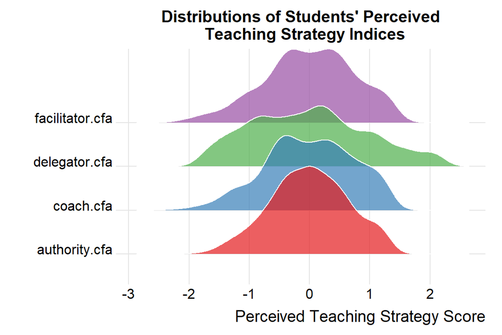

```r
var.name <-c( "authority.cfa", "coach.cfa", "facilitator.cfa", "delegator.cfa")
# <-c( "Cooporative.avg", "Deductive.avg", "Demonstration.avg",
#              "Inductive.avg", "Integrative.avg", "LectureType.avg",
#              "Repetitive.avg")
all.composite.scores <-finalDat[, var.name]
names(all.composite.scores) <- c("authority.cfa", "coach.cfa", "facilitator.cfa", "delegator.cfa")

# For older versions of tidyr
long_data <- all.composite.scores %>%
  pivot_longer(
    cols = c(authority.cfa, coach.cfa, facilitator.cfa, delegator.cfa),  # Columns to reshape
    names_to = "variable",          # New column name for variable names
    values_to = "value"             # New column name for values
  )

## Summarized stats

summary_stats <- long_data %>%
  group_by(variable) %>%
  summarise(
    mean_val = mean(value),
    median_val = median(value),
    sd_val = sd(value),
    n = n(),
    .groups = 'drop'
  )

# Create ridge plot with ggridges and convert to plotly
ridge_gg <- ggplot(long_data, aes(x = value, y = variable, fill = variable
  )) +
  geom_density_ridges(
    alpha = 0.7,
    scale = 2,  # Adjust overlap
    color = "white",
    size = 0.5,
     ) +
  scale_fill_brewer(palette = "Set1") +
  #theme(plot.title = element_text(hjust = 0)) +
  theme_ridges() +
  labs(
    title = "Distributions of Students' Perceived \n Teaching Strategy Indices",
    x = "Perceived Teaching Strategy Score",
    y = ""
  ) +
  theme(legend.position = "none",
        plot.title = element_text(hjust = 0.5))

ridge_gg
```

## 9.1 Teaching Strategies Modulate the Triad

Teaching strategies are not merely methods of content delivery; they are powerful environmental forces that directly shape students’ emotional and self-evaluative landscapes.

**Teacher-Centered Strategies**

**Authority (Lecture)**: The instructor serves as the primary source of knowledge, delivering content through formal lecture while students listen and take notes. Information flows mainly from instructor to student, with the teacher controlling pace and structure. This approach efficiently introduces foundational concepts but places students in a largely receptive role.

**Demonstrator (Coach)**: The instructor models procedures and provides guided practice, then invites students to attempt similar problems while offering immediate feedback and corrections. This scaffolded, interactive approach is effective for procedural skills, bridging teacher-centered and student-centered instruction by retaining instructor guidance while requiring active student engagement.

**Student-Centered Strategies**

**Facilitator Approach (Activity-Based)**: The instructor designs hands-on, exploratory activities and shifts to a guiding role, posing problems and supporting students as they investigate and discover patterns. The emphasis is on process over product, promoting deeper conceptual understanding through direct engagement with mathematical ideas.

**Delegator Approach (Group-Based)**: The instructor assigns students to cooperative groups and delegates responsibility for learning to the students themselves. Group members explain concepts to one another, discuss strategies, and produce shared outcomes. This approach fosters peer interaction and teamwork but depends heavily on group dynamics and individual accountability.

## 9.2 Create Single Composite Score for the Classification

```r
var.name <-c("authority.cfa", "coach.cfa", "facilitator.cfa", "delegator.cfa")
teachingIdx <- na.omit(finalDat[, var.name])
names(teachingIdx) <- c("authority.cfa", "coach.cfa", "facilitator.cfa", "delegator.cfa")
```

```r
final.var <- c("sex", "race", "class", "major", "math.level", "modality", "Anxiety.mea.cfa", "Anxiety.mla.cfa", "SelfEfficacy.cfa", "Technology.cfa",
               "Cooporative.cfa", "Deductive.cfa", "Demonstration.cfa", "Inductive.cfa", "Integrative.cfa", "LectureType.cfa",
               "Repetitive.cfa", "Engage.cfa", "Resource.cfa", "Teacher.ctrd.cfa", "Student.ctrd.cfa")
final.clean.analytic.data <- Anxiety.Analytic.Data[, final.var]
final.name <- c("sex", "race", "class", "major", "math.level", "modality", "mea", "mla", "selfEfficacy", "technology",
               "cooperative", "deductive", "demonstrative", "inductive", "integrative", "lecture",
               "repetitive", "engage", "resource", "teacher.ctrd", "student.ctrd")
colnames(final.clean.analytic.data) <- final.name
#write.csv(final.clean.analytic.data, "C:\\Users\\75CPENG\\OneDrive - West Chester University of PA\\Desktop\\cpeng\\WCU-Research\\2026\\AnxietyPapers\\CleanData\\TidyRegData.csv")
```

```r
#Anxiety.Analytic.Data <- read.csv("C:\\Users\\75CPENG\\OneDrive - West Chester University of PA\\Desktop\\cpeng\\WCU-Teaching\\2025Fall\\MathAxiety\\Anxiety.Analytic.Data.csv")
```

```r
group.var <- c("sex", "math.level", "Anxiety.mea.cfa", "Anxiety.mla.cfa", "SelfEfficacy.cfa", "Student.ctrd.cfa","Teacher.ctrd.cfa")
group.strategy <- Anxiety.Analytic.Data[, group.var]
names(group.strategy) <-c("gender", "math.level", "anxiety.mea", "anxiety.mla", "self.efficacy", "student.ctrd", "teacher.ctrd")
##
group.strategy.loess <- data.frame(
  mla.index <- rep(group.strategy$anxiety.mla, 2),
  gender <- rep(group.strategy$gender,2),
  factor.index <-c(group.strategy$student.ctrd, group.strategy$teacher.ctrd),
  RelatedFactors <- rep(c("student.ctrd", "teacher.ctrd"), each = 693),
  math.level <- rep(group.strategy$math.level,2)
)
names(group.strategy.loess) <- c("mla.index", "gender", "factor.index", "RelatedFactors", "math.level")

level01.id <- which(group.strategy.loess$math.level %in% c("math02", "stats"))
level02.id <- which(group.strategy.loess$math.level %in% c("math03", "math04"))
##
level01.data <-group.strategy.loess[level01.id , ]
level01.data$gender.level <- paste0(level01.data$gender, " & ", level01.data$math.level)
##
level02.data <-group.strategy.loess[level02.id , ]
level02.data$gender.level <- paste0(level02.data$gender, " & ", level02.data$math.level)
```

```r
gg <- ggplot(level01.data, aes(x = mla.index, y = factor.index, color = RelatedFactors, group = RelatedFactors)) +
  #geom_point(alpha = 0.5, size = 1.5) +
  geom_smooth(method = "loess", span = 0.75, se = FALSE, size = 1) +
  facet_wrap(~ gender.level, ncol = 2, nrow = 2) +
  scale_color_viridis_d(option = "plasma") +
  labs(title = "Loess Plots: Teaching Strategy vs Learning Anxiety",
       x = "Math Learning Anxiety",
       y = "Teaching Strategy Index") +
  theme_minimal() +
  theme(
    strip.background = element_rect(fill = "lightgray"),
    strip.text = element_text(face = "bold"),
    plot.title = element_text(hjust = 0.5)
  )

##gg
```

```r
gg <- ggplot(level02.data, aes(x = mla.index, y = factor.index, color = RelatedFactors, group = RelatedFactors)) +
  #geom_point(alpha = 0.5, size = 1.5) +
  geom_smooth(method = "loess", span = 0.75, se = FALSE, size = 1) +
  facet_wrap(~ gender.level, ncol = 2, nrow = 2) +
  scale_color_viridis_d(option = "plasma") +
  labs(title = "Loess Plots: Teaching Strategy vs Learning Anxiety",
       x = "Math Learning Anxiety",
       y = "Teaching Strategy Index") +
  theme_minimal() +
  theme(
    strip.background = element_rect(fill = "lightgray"),
    strip.text = element_text(face = "bold"),
    plot.title = element_text(hjust = 0.5)
  )
```

```r
group.var <- c("sex", "math.level", "Anxiety.mea.cfa", "Anxiety.mla.cfa", "SelfEfficacy.cfa", "Student.ctrd.cfa","Teacher.ctrd.cfa")
group.strategy <- Anxiety.Analytic.Data[, group.var]
names(group.strategy) <-c("gender", "math.level", "anxiety.mea", "anxiety.mla", "self.efficacy", "student.ctrd", "teacher.ctrd")
##
group.strategy.loess.mea <- data.frame(
  mea.index <- rep(group.strategy$anxiety.mea, 2),
  gender <- rep(group.strategy$gender,2),
  factor.index <-c(group.strategy$student.ctrd, group.strategy$teacher.ctrd),
  RelatedFactors <- rep(c("student.ctrd", "teacher.ctrd"), each = 693),
  math.level <- rep(group.strategy$math.level,2)
)
names(group.strategy.loess.mea) <- c("mea.index", "gender", "factor.index", "RelatedFactors", "math.level")

level01.id.mea <- which(group.strategy.loess.mea$math.level %in% c("math02", "stats"))
level02.id.mea <- which(group.strategy.loess.mea$math.level %in% c("math03", "math04"))
##
level01.data.mea <-group.strategy.loess.mea[level01.id.mea, ]
level01.data.mea$gender.level <- paste0(level01.data.mea$gender, " & ", level01.data.mea$math.level)
##
level02.data.mea <-group.strategy.loess.mea[level02.id.mea, ]
level02.data.mea$gender.level <- paste0(level02.data.mea$gender, " & ", level02.data.mea$math.level)
```

```r
gg <- ggplot(level01.data.mea, aes(x = mea.index, y = factor.index, color = RelatedFactors, group = RelatedFactors)) +
  #geom_point(alpha = 0.5, size = 1.5) +
  geom_smooth(method = "loess", span = 0.75, se = FALSE, size = 1) +
  facet_wrap(~ gender.level, ncol = 2, nrow = 2) +
  scale_color_viridis_d(option = "plasma") +
  labs(title = "Loess Plots: Teaching Strategy vs Test Anxiety",
       x = "Math Test Anxiety",
       y = "Teaching Strategy Index") +
  theme_minimal() +
  theme(
    strip.background = element_rect(fill = "lightgray"),
    strip.text = element_text(face = "bold"),
    plot.title = element_text(hjust = 0.5)
  )
```

```r
gg <- ggplot(level02.data.mea, aes(x = mea.index, y = factor.index, color = RelatedFactors, group = RelatedFactors)) +
  #geom_point(alpha = 0.5, size = 1.5) +
  geom_smooth(method = "loess", span = 0.75, se = FALSE, size = 1) +
  facet_wrap(~ gender.level, ncol = 2, nrow = 2) +
  scale_color_viridis_d(option = "plasma") +
  labs(title = "Loess Plots: Teaching Strategy vs Test Anxiety",
       x = "Math Test Anxiety",
       y = "Teaching Strategy Index") +
  theme_minimal() +
  theme(
    strip.background = element_rect(fill = "lightgray"),
    strip.text = element_text(face = "bold"),
    plot.title = element_text(hjust = 0.5)
  )

 gg
```

[output not shown]

# 10 Linear Regression Analysis

This section moves from the previous descriptive analyses to a regression analysis of the association between math anxiety and related factors. We examine two distinct but interconnected types of math anxiety, evaluation anxiety and learning anxiety, while temporarily setting aside their interconnection.

The regression model also incorporates the two teaching strategies as predictor variables. We also realized that the two variables are correlated.

## 10.1 Factors Associated with Evaluation Anxiety

```r
reg.data <- finalDat
reg.name <- c("ID", "sex", "race", "class", "major",  "math.level",  "modality", "MEA",  "MLA", "SelfEfficacy", "Technology", "authority",  "coach",  "facilitator", "delegator", "teacherCtrd", "studentCtrd", "ABE", "ISE", "Resource")
colnames(reg.data) = reg.name
```

### 10.1.1 Pairwise Comparison

We used an ANOVA approach to assess differences in anxiety across genders and learning modalities.

- **Gender**

```r
lm.m1 <- lm(MEA ~ sex, data = reg.data)
lm.m1
```

```
Call:
lm(formula = MEA ~ sex, data = reg.data)

Coefficients:
(Intercept)      sexmale
     0.1557      -0.4865
```

```r
aov.m1 <- aov(MEA ~ sex, data = reg.data)
summary(aov.m1)
```

```
             Df Sum Sq Mean Sq F value   Pr(>F)
sex           1   35.7   35.72   38.93 7.66e-10 ***
Residuals   691  634.0    0.92
---
Signif. codes:  0 '***' 0.001 '**' 0.01 '*' 0.05 '.' 0.1 ' ' 1
```

```r
TukeyHSD(aov.m1)
```

```
  Tukey multiple comparisons of means
    95% family-wise confidence level

Fit: aov(formula = MEA ~ sex, data = reg.data)

$sex
                  diff        lwr        upr p adj
male-female -0.4865496 -0.6396601 -0.3334391     0
```

```r
lm.m2 <- lm(MLA ~ sex, data = reg.data)
lm.m2
```

```
Call:
lm(formula = MLA ~ sex, data = reg.data)

Coefficients:
(Intercept)      sexmale
    0.02504     -0.08348
```

```r
aov.m2 <- aov(MLA ~ sex, data = reg.data)
summary(aov.m2)
```

```
             Df Sum Sq Mean Sq F value Pr(>F)
sex           1   1.05  1.0516   5.688 0.0174 *
Residuals   691 127.76  0.1849
---
Signif. codes:  0 '***' 0.001 '**' 0.01 '*' 0.05 '.' 0.1 ' ' 1
```

```r
TukeyHSD(aov.m2)
```

```
  Tukey multiple comparisons of means
    95% family-wise confidence level

Fit: aov(formula = MLA ~ sex, data = reg.data)

$sex
                   diff        lwr        upr     p adj
male-female -0.08348243 -0.1522114 -0.0147535 0.0173538
```

- **Modality**

```r
lm.m1 <- lm(MEA ~ modality, data = reg.data)
lm.m1
```

```
Call:
lm(formula = MEA ~ modality, data = reg.data)

Coefficients:
        (Intercept)  modalityKinesthetic       modalityVisual
           -0.08859              0.14886              0.07433
```

```r
aov.m1 <- aov(MEA ~ modality, data = reg.data)
summary(aov.m1)
```

```
             Df Sum Sq Mean Sq F value Pr(>F)
modality      2    2.4  1.1810   1.221  0.296
Residuals   690  667.4  0.9672
```

```r
TukeyHSD(aov.m1)
```

```
  Tukey multiple comparisons of means
    95% family-wise confidence level

Fit: aov(formula = MEA ~ modality, data = reg.data)

$modality
                            diff         lwr       upr     p adj
Kinesthetic-Auditory  0.14886361 -0.07848269 0.3762099 0.2738151
Visual-Auditory       0.07432897 -0.16104121 0.3096992 0.7387166
Visual-Kinesthetic   -0.07453463 -0.27549736 0.1264281 0.6587111
```

```r
lm.m2 <- lm(MLA ~ modality, data = reg.data)
lm.m2
```

```
Call:
lm(formula = MLA ~ modality, data = reg.data)

Coefficients:
        (Intercept)  modalityKinesthetic       modalityVisual
          -0.005718             0.007355             0.002638
```

```r
aov.m2 <- aov(MLA ~ modality, data = reg.data)
summary(aov.m2)
```

```
             Df Sum Sq Mean Sq F value Pr(>F)
modality      2   0.01 0.00314   0.017  0.983
Residuals   690 128.80 0.18667
```

```r
TukeyHSD(aov.m2)
```

```
  Tukey multiple comparisons of means
    95% family-wise confidence level

Fit: aov(formula = MLA ~ modality, data = reg.data)

$modality
                             diff         lwr        upr     p adj
Kinesthetic-Auditory  0.007355474 -0.09251984 0.10723078 0.9836399
Visual-Auditory       0.002637853 -0.10076242 0.10603813 0.9980225
Visual-Kinesthetic   -0.004717620 -0.09300239 0.08356715 0.9913530
```

- **Grouped Teaching Strategies**

```r
m1 <- lm(MEA ~ teacherCtrd + studentCtrd, data =reg.data)
summary(m1)
```

```
Call:
lm(formula = MEA ~ teacherCtrd + studentCtrd, data = reg.data)

Residuals:
     Min       1Q   Median       3Q      Max
-3.08262 -0.60251 -0.02056  0.74024  2.08813

Coefficients:
              Estimate Std. Error t value Pr(>|t|)
(Intercept) -0.0007998  0.0359646  -0.022  0.98226
teacherCtrd -0.2819209  0.0912180  -3.091  0.00208 **
studentCtrd -0.1076775  0.0748596  -1.438  0.15078
---
Signif. codes:  0 '***' 0.001 '**' 0.01 '*' 0.05 '.' 0.1 ' ' 1

Residual standard error: 0.9468 on 690 degrees of freedom
Multiple R-squared:  0.07655,   Adjusted R-squared:  0.07387
F-statistic:  28.6 on 2 and 690 DF,  p-value: 1.169e-12
```

```r
m2 <- lm(MLA ~ teacherCtrd + studentCtrd, data =reg.data)
summary(m2)
```

```
Call:
lm(formula = MLA ~ teacherCtrd + studentCtrd, data = reg.data)

Residuals:
     Min       1Q   Median       3Q      Max
-1.05115 -0.28467 -0.08155  0.21402  1.58222

Coefficients:
             Estimate Std. Error t value Pr(>|t|)
(Intercept) -0.002299   0.015126  -0.152   0.8792
teacherCtrd -0.315739   0.038364  -8.230 9.33e-16 ***
studentCtrd  0.078213   0.031484   2.484   0.0132 *
---
Signif. codes:  0 '***' 0.001 '**' 0.01 '*' 0.05 '.' 0.1 ' ' 1

Residual standard error: 0.3982 on 690 degrees of freedom
Multiple R-squared:  0.1507,    Adjusted R-squared:  0.1482
F-statistic: 61.21 on 2 and 690 DF,  p-value: < 2.2e-16
```

For the association analysis, we will build two regression models. Both models include a common set of demographic predictors. The first model uses individual teaching strategies as additional predictors, while the second uses grouped teaching strategies.

# 11 Regression Analysis of MEA and MLA

To examine the associations between mathematics anxiety (MLA) and the predictor variables, we initially fitted a series of multiple linear regression models. However, residual diagnostics revealed that the assumption of linearity was violated: the LOESS curves in the Residuals vs. Fitted plots were not approximately parallel to the horizontal axis, indicating systematic non-linear patterns in the residuals. Adding polynomial (quadratic) terms did not resolve this issue, suggesting that the non-linear relationships were more complex than a simple quadratic trend. Given that the functional form of the associations between several predictors and MLA was unknown and could not be adequately captured by parametric polynomial specification, Generalized Additive Models (GAMs) were fitted using the mgcv package (version 1.9-0; Wood, 2017) in R. GAMs offer a data-driven approach to modeling non-linear relationships by estimating smooth functions from the data rather than imposing a pre-specified parametric form (Hastie & Tibshirani, 1990).

Model results are reported in two forms. First, a consolidated table presents the EDF, F-statistic, and exact p-value for each smooth term, and the estimate, standard error, t-value, and exact p-value for each parametric (linear) term. EDF values are reported to communicate the complexity of each non-linear relationship: EDF ≈ 1 indicates a linear relationship, EDF between 1.5 and 2.5 indicates moderate non-linearity, and EDF > 2.5 indicates substantial non-linearity (Wood, 2017). Second, plots of the estimated smooth functions are presented for all significant smooth terms, with shaded regions representing 95% confidence intervals and rug plots at the bottom indicating the distribution of the data. These plots allow the shape of each non-linear association to be visually inspected. Full model summaries, diagnostic plots, and concurvity diagnostics are provided in the Supplementary Materials.

## 11.1 Linear Regression Using Individual Teaching Strategies

The analysis begins with a regression model incorporating all individual teaching approaches alongside demographic and related variables as predictors.

- R function for Bootstrap CI for regression coefficients

```r
# Install if you haven't already: install.packages("boot")
library(boot)

#' Bootstrap CIs using the boot package
#' @param model A fitted model object from lm().
#' @param n_boot Number of bootstrap resamples.
#' @return A data frame of BCa confidence intervals.
boot_lm_bca <- function(model, n_boot = 10000) {

  # Define the statistic function for the boot package
  # 'data' is the resampled dataframe, 'indices' are the row indices
  boot_stat <- function(data, indices) {
    # Resample the data
    d <- data[indices, ]
    # Refit the model
    fit <- lm(formula(model), data = d)
    # Return the coefficients
    return(coef(fit))
  }

  # Run the bootstrap
  # Note: we pass model$model to ensure we are bootstrapping the exact data used in lm()
  boot_obj <- boot(data = model$model, statistic = boot_stat, R = n_boot)

  # Extract BCa intervals for each coefficient
  n_coefs <- length(coef(model))
  results <- data.frame(
    Term = names(coef(model)),
    Estimate = coef(model),
    Boot_SE = apply(boot_obj$t, 2, sd),
    CI_Lower = NA,
    CI_Upper = NA,
    row.names = NULL
  )

  for (i in 1:n_coefs) {
    # Calculate BCa intervals (type = "bca")
    ci <- tryCatch(
      boot.ci(boot_obj, type = "bca", index = i),
      error = function(e) NULL
    )

    if (!is.null(ci)) {
      # BCa interval is stored in the 4th and 5th elements of the bca list
      results$CI_Lower[i] <- ci$bca[4]
      results$CI_Upper[i] <- ci$bca[5]
    } else {
      # Fallback to percentile if BCa fails (rare)
      ci_pct <- boot.ci(boot_obj, type = "perc", index = i)
      results$CI_Lower[i] <- ci_pct$perc[4]
      results$CI_Upper[i] <- ci_pct$perc[5]
    }
  }

  return(results)
}
```

- Combine lm() and Bootstrap confidence intervals

```r
lm.boot.table <- function(model, n_boot = 10000){
   boot.model = boot_lm_bca(model,n_boot = 10000)
   cbind(round(summary(model)$coef,4), round(boot.model[, -(1:2)], 4))
}
```

- **PAM regression on MEA with Individual Teaching Strategies - Left Panel of Table 3**

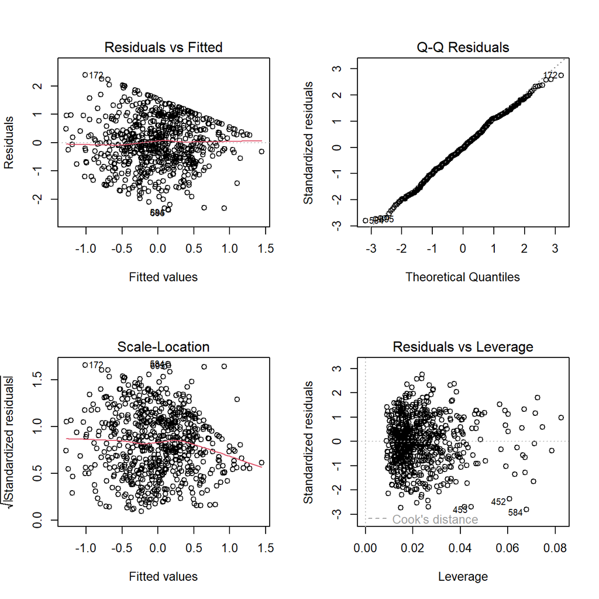

```r
###
mea.ind.lm <- lm(MEA ~ sex + race + class + major + math.level + modality + Technology + authority + coach + facilitator + delegator + ABE + ISE + Resource, data = reg.data )
stepwise.mea.ind0 <- stepAIC(mea.ind.lm, direction = "both", trace = 0)
#kable(summary(mea.ind.lm)$coef, caption = "Table 1. Tentative model with all predictor variables: Imfluence of individual teaching strategies on MEA")
#pander(summary(stepwise.mea.ind)$coef, caption = "Table 3 (left panel). Association between math evaluation anxiety and perceived individual teaching strategies adjusted by demographics and environmental factors")
par(mfrow = c(2,2))
plot(stepwise.mea.ind0)
```

```r
summary(stepwise.mea.ind0)
```

```
Call:
lm(formula = MEA ~ sex + class + math.level + Technology + facilitator +
    ABE + ISE + Resource, data = reg.data)

Residuals:
     Min       1Q   Median       3Q      Max
-2.37615 -0.55566 -0.02609  0.63083  2.38298

Coefficients:
                  Estimate Std. Error t value Pr(>|t|)
(Intercept)       0.048470   0.102705   0.472 0.637124
sexmale          -0.390263   0.077546  -5.033 6.21e-07 ***
classyr2          0.118231   0.082890   1.426 0.154224
classyr3          0.301859   0.099333   3.039 0.002466 **
classyr4          0.681998   0.204551   3.334 0.000902 ***
classyr5+         0.314669   0.149145   2.110 0.035240 *
math.levelmath02  0.065677   0.121071   0.542 0.587676
math.levelmath03  0.097075   0.130023   0.747 0.455566
math.levelmath04 -0.006868   0.155903  -0.044 0.964875
math.levelother  -0.403914   0.162211  -2.490 0.013011 *
math.levelstats  -0.226350   0.123292  -1.836 0.066813 .
Technology       -0.242105   0.045458  -5.326 1.37e-07 ***
facilitator      -0.305849   0.047383  -6.455 2.07e-10 ***
ABE               0.300739   0.080766   3.724 0.000213 ***
ISE              -0.199429   0.059771  -3.337 0.000895 ***
Resource          0.192048   0.092632   2.073 0.038527 *
---
Signif. codes:  0 '***' 0.001 '**' 0.01 '*' 0.05 '.' 0.1 ' ' 1

Residual standard error: 0.8774 on 677 degrees of freedom
Multiple R-squared:  0.2218,    Adjusted R-squared:  0.2045
F-statistic: 12.86 on 15 and 677 DF,  p-value: < 2.2e-16
```

```r
gam.m0 <- gam(MEA ~ sex +
                #class +
                #math.level +
                s(SelfEfficacy, bs = "cs", k = 8) +
                          s(Technology, bs = "cs", k = 6) +
                          #authority +
                          #coach +
                          s(facilitator, bs = "cs", k = 4) +
                          #delegator +
                          #s(ISE, bs = "cs", k = 5) +
                          ABE,
                          #s(ABE, bs = "cs", k = 5),# +
                          #s(Resource, bs = "cs", k = 4),
                          #s(Engage, bs = "cs"),
              data = reg.data,
              select = TRUE,      # Enable automatic term selection
              method = "REML")    # Use REML for smoothness selection
#gam.check(gam.m0)
```

```r
sum.gam.m0 <- summary(gam.m0)
sum.gam.m0
```

```
Family: gaussian
Link function: identity

Formula:
MEA ~ sex + s(SelfEfficacy, bs = "cs", k = 8) + s(Technology,
    bs = "cs", k = 6) + s(facilitator, bs = "cs", k = 4) + ABE

Parametric coefficients:
            Estimate Std. Error t value Pr(>|t|)
(Intercept)  0.09766    0.03920   2.492 0.012955 *
sexmale     -0.30700    0.07197  -4.266 2.27e-05 ***
ABE          0.24509    0.07320   3.348 0.000858 ***
---
Signif. codes:  0 '***' 0.001 '**' 0.01 '*' 0.05 '.' 0.1 ' ' 1

Approximate significance of smooth terms:
                  edf Ref.df      F  p-value
s(SelfEfficacy) 2.519      7 15.618  < 2e-16 ***
s(Technology)   1.777      5  4.117 7.95e-06 ***
s(facilitator)  1.421      3  9.752  < 2e-16 ***
---
Signif. codes:  0 '***' 0.001 '**' 0.01 '*' 0.05 '.' 0.1 ' ' 1

R-sq.(adj) =  0.282   Deviance explained =   29%
-REML =  869.5  Scale est. = 0.69515   n = 693
```

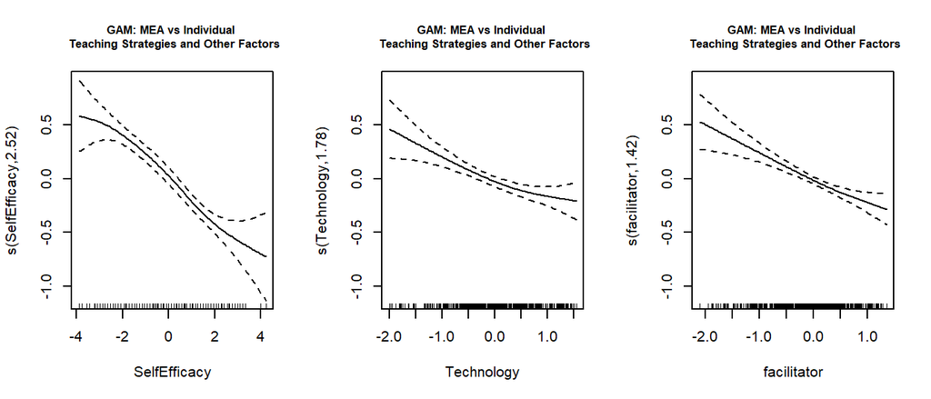

```r
par(mfrow= c(1,3))
plot(gam.m0,  main = "GAM: MEA vs Individual \n Teaching Strategies and Other Factors",
     cex.main = 0.8)
```

```r
# --- 5. Check for concurvity (collinearity in GAMs) ---
# High concurvity can make estimates unstable. Values > 0.8 are concerning.
concurvity(gam.m0, full = TRUE)
```

```
              para s(SelfEfficacy) s(Technology) s(facilitator)
worst    0.3525945      0.11701138    0.13927325     0.11774709
observed 0.3525945      0.10910694    0.07983545     0.11501246
estimate 0.3525945      0.04201566    0.05363550     0.08610776
```

The figure above reveals a clear pattern of non-constant residual variance (heteroscedasticity) as the fitted values increase. Because the response variable includes negative values, a standard Box-Cox transformation is not applicable for identifying a power transformation. Instead, we will use bootstrap confidence intervals for all regression coefficients to assess their significance, thereby maintaining the response variable on its original scale.

```r
pander(lm.boot.table(stepwise.mea.ind, 5000))
```

[output not shown]

- **PAM regression on MLA with Individual Teaching Strategies - Right Panel of Table 3**

```r
mla.lm.data.ind <- na.omit(reg.data[,-c(1, 2, 21,22)])
mla.ind.lm <- lm(MLA ~ sex + race + class + major + math.level + modality + Technology + authority + coach + facilitator + delegator + ABE + ISE + Resource, data = reg.data)
stepwise.mla.ind <- stepAIC(mla.ind.lm, direction = "both", trace = 0)
#kable(summary(mea.ind.lm)$coef, caption = "Table 1. Tentative model with all predictor variables: Imfluence of individual teaching strategies on MEA")
pander(summary(stepwise.mla.ind)$coef, caption = "Table 3 (right panel). Association between math learning anxiety and perceived individual teaching strategies adjusted by demographics and environmental factors")
```

Table 3 (right panel). Association between math learning anxiety and perceived individual teaching strategies adjusted by demographics and environmental factors

|  | Estimate | Std. Error | t value | Pr(>\|t\|) |
| --- | --- | --- | --- | --- |
| **(Intercept)** | 0.02175 | 0.07621 | 0.2854 | 0.7755 |
| **raceBlack** | 0.1898 | 0.08104 | 2.342 | 0.01947 |
| **raceother** | 0.02439 | 0.08139 | 0.2997 | 0.7645 |
| **racewhite** | 0.01569 | 0.06594 | 0.238 | 0.812 |
| **classyr2** | -0.0009921 | 0.03555 | -0.02791 | 0.9777 |
| **classyr3** | 0.08697 | 0.04279 | 2.033 | 0.04248 |
| **classyr4** | 0.2866 | 0.08798 | 3.257 | 0.001181 |
| **classyr5+** | 0.08253 | 0.06366 | 1.296 | 0.1953 |
| **math.levelmath02** | -0.0392 | 0.0514 | -0.7627 | 0.4459 |
| **math.levelmath03** | -0.1054 | 0.0551 | -1.913 | 0.0562 |
| **math.levelmath04** | -0.1331 | 0.0664 | -2.004 | 0.04544 |
| **math.levelother** | -0.1863 | 0.06942 | -2.684 | 0.007452 |
| **math.levelstats** | -0.09247 | 0.05281 | -1.751 | 0.08037 |
| **Technology** | -0.1288 | 0.01919 | -6.712 | 4.069e-11 |
| **authority** | -0.09727 | 0.04779 | -2.035 | 0.04221 |
| **facilitator** | -0.1517 | 0.04533 | -3.347 | 0.0008628 |
| **delegator** | 0.05245 | 0.02227 | 2.355 | 0.0188 |
| **ISE** | -0.07262 | 0.02455 | -2.959 | 0.003197 |
| **Resource** | 0.147 | 0.04032 | 3.646 | 0.0002866 |

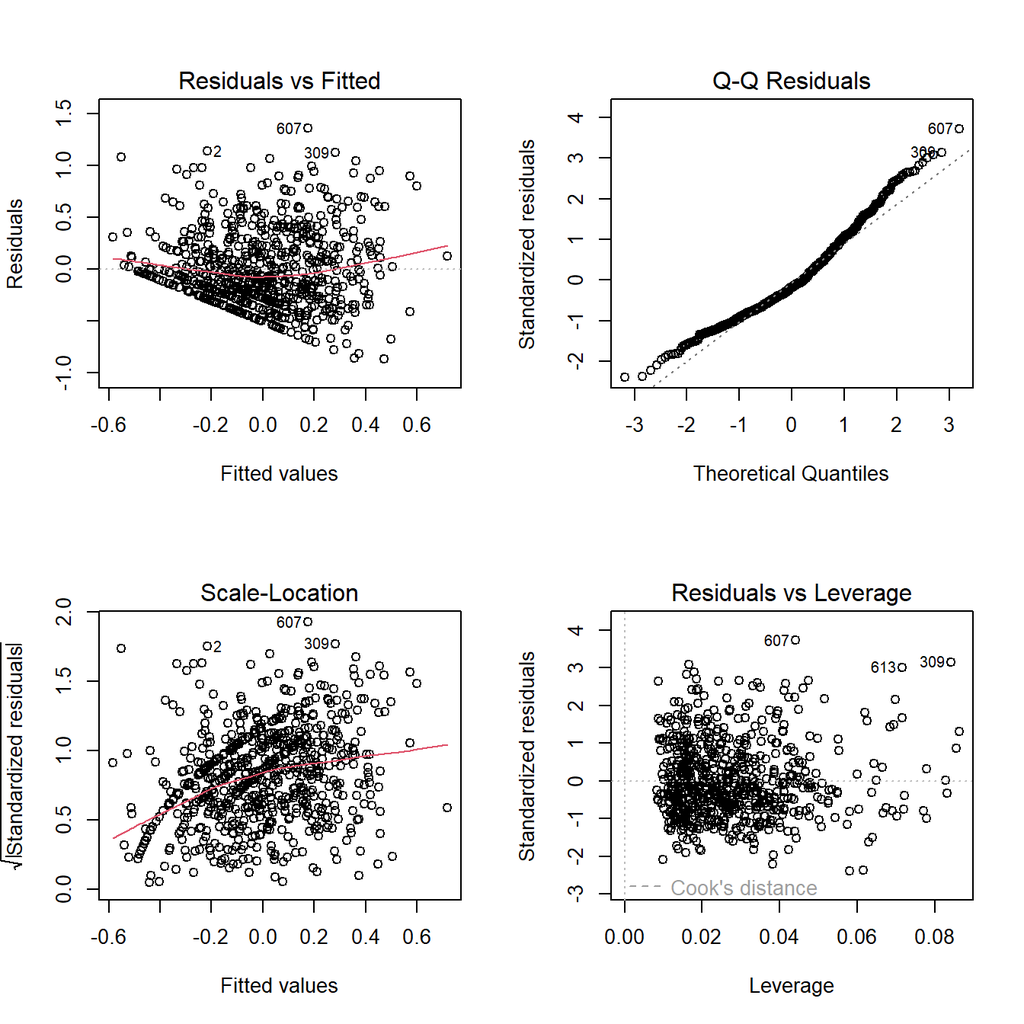

```r
par(mfrow = c(2,2))
plot(stepwise.mla.ind )
```

```r
summary(stepwise.mla.ind)
```

```
Call:
lm(formula = MLA ~ race + class + math.level + Technology + authority +
    facilitator + delegator + ISE + Resource, data = reg.data)

Residuals:
     Min       1Q   Median       3Q      Max
-0.86580 -0.26143 -0.06534  0.21965  1.36035

Coefficients:
                   Estimate Std. Error t value Pr(>|t|)
(Intercept)       0.0217464  0.0762080   0.285 0.775459
raceBlack         0.1898118  0.0810437   2.342 0.019466 *
raceother         0.0243941  0.0813868   0.300 0.764475
racewhite         0.0156941  0.0659448   0.238 0.811962
classyr2         -0.0009921  0.0355527  -0.028 0.977745
classyr3          0.0869720  0.0427873   2.033 0.042478 *
classyr4          0.2865955  0.0879815   3.257 0.001181 **
classyr5+         0.0825293  0.0636615   1.296 0.195290
math.levelmath02 -0.0392020  0.0513980  -0.763 0.445901
math.levelmath03 -0.1053959  0.0551002  -1.913 0.056196 .
math.levelmath04 -0.1330770  0.0663970  -2.004 0.045442 *
math.levelother  -0.1863208  0.0694178  -2.684 0.007452 **
math.levelstats  -0.0924706  0.0528051  -1.751 0.080372 .
Technology       -0.1288059  0.0191896  -6.712 4.07e-11 ***
authority        -0.0972673  0.0477903  -2.035 0.042212 *
facilitator      -0.1517133  0.0453305  -3.347 0.000863 ***
delegator         0.0524466  0.0222695   2.355 0.018804 *
ISE              -0.0726235  0.0245455  -2.959 0.003197 **
Resource          0.1470104  0.0403181   3.646 0.000287 ***
---
Signif. codes:  0 '***' 0.001 '**' 0.01 '*' 0.05 '.' 0.1 ' ' 1

Residual standard error: 0.3735 on 674 degrees of freedom
Multiple R-squared:  0.2701,    Adjusted R-squared:  0.2506
F-statistic: 13.86 on 18 and 674 DF,  p-value: < 2.2e-16
```

```r
mod.m1 <- lm(MLA ~ sex + race + class + major + math.level + modality + Technology + authority + coach + facilitator + delegator + ABE + ISE + Resource, data = reg.data)
summary(mod.m1)
```

```
Call:
lm(formula = MLA ~ sex + race + class + major + math.level +
    modality + Technology + authority + coach + facilitator +
    delegator + ABE + ISE + Resource, data = reg.data)

Residuals:
     Min       1Q   Median       3Q      Max
-0.86774 -0.25377 -0.07336  0.21391  1.41627

Coefficients:
                     Estimate Std. Error t value Pr(>|t|)
(Intercept)          0.049611   0.091860   0.540 0.589326
sexmale             -0.023623   0.033639  -0.702 0.482766
raceBlack            0.192809   0.081651   2.361 0.018494 *
raceother            0.021987   0.081863   0.269 0.788337
racewhite            0.008807   0.066590   0.132 0.894817
classyr2            -0.001382   0.035864  -0.039 0.969265
classyr3             0.084655   0.043217   1.959 0.050548 .
classyr4             0.299315   0.092237   3.245 0.001233 **
classyr5+            0.070687   0.065012   1.087 0.277307
majorHealth         -0.012263   0.063149  -0.194 0.846085
majorOther          -0.056479   0.049884  -1.132 0.257954
majorSTEM           -0.054776   0.042600  -1.286 0.198949
math.levelmath02    -0.046217   0.055353  -0.835 0.404044
math.levelmath03    -0.129275   0.063788  -2.027 0.043096 *
math.levelmath04    -0.132417   0.070280  -1.884 0.059982 .
math.levelother     -0.188676   0.072615  -2.598 0.009576 **
math.levelstats     -0.114662   0.061773  -1.856 0.063870 .
modalityKinesthetic  0.053398   0.038754   1.378 0.168705
modalityVisual       0.040217   0.039798   1.011 0.312621
Technology          -0.123041   0.020047  -6.138 1.44e-09 ***
authority           -0.077190   0.051927  -1.487 0.137617
coach               -0.043201   0.043083  -1.003 0.316347
facilitator         -0.135196   0.049864  -2.711 0.006875 **
delegator            0.060033   0.022896   2.622 0.008943 **
ABE                  0.034625   0.035308   0.981 0.327126
ISE                 -0.075190   0.025933  -2.899 0.003862 **
Resource             0.145092   0.041743   3.476 0.000542 ***
---
Signif. codes:  0 '***' 0.001 '**' 0.01 '*' 0.05 '.' 0.1 ' ' 1

Residual standard error: 0.3737 on 666 degrees of freedom
Multiple R-squared:  0.2779,    Adjusted R-squared:  0.2497
F-statistic: 9.859 on 26 and 666 DF,  p-value: < 2.2e-16
```

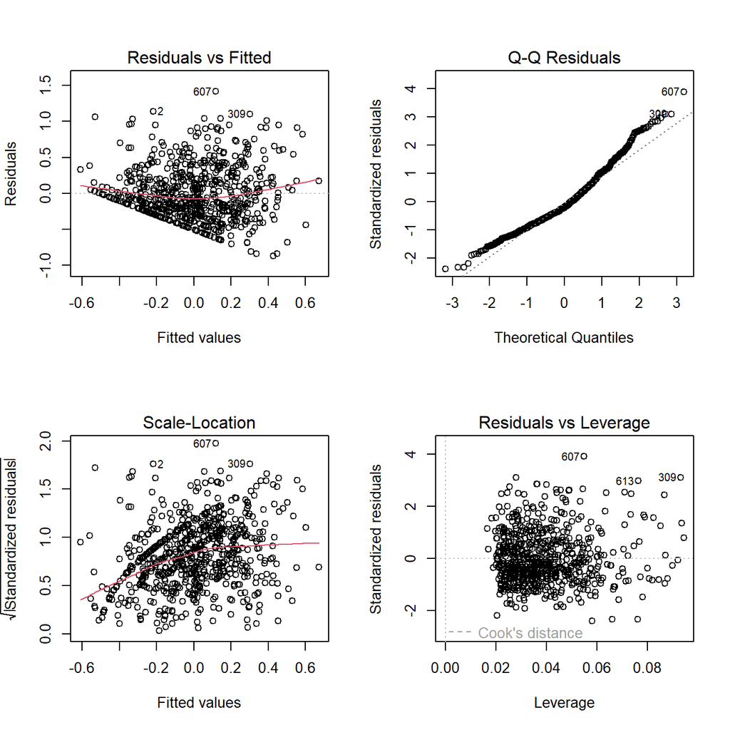

```r
par(mfrow=c(2,2))
plot(mod.m1)
```

```r
summary(mod.m1)
```

```
Call:
lm(formula = MLA ~ sex + race + class + major + math.level +
    modality + Technology + authority + coach + facilitator +
    delegator + ABE + ISE + Resource, data = reg.data)

Residuals:
     Min       1Q   Median       3Q      Max
-0.86774 -0.25377 -0.07336  0.21391  1.41627

Coefficients:
                     Estimate Std. Error t value Pr(>|t|)
(Intercept)          0.049611   0.091860   0.540 0.589326
sexmale             -0.023623   0.033639  -0.702 0.482766
raceBlack            0.192809   0.081651   2.361 0.018494 *
raceother            0.021987   0.081863   0.269 0.788337
racewhite            0.008807   0.066590   0.132 0.894817
classyr2            -0.001382   0.035864  -0.039 0.969265
classyr3             0.084655   0.043217   1.959 0.050548 .
classyr4             0.299315   0.092237   3.245 0.001233 **
classyr5+            0.070687   0.065012   1.087 0.277307
majorHealth         -0.012263   0.063149  -0.194 0.846085
majorOther          -0.056479   0.049884  -1.132 0.257954
majorSTEM           -0.054776   0.042600  -1.286 0.198949
math.levelmath02    -0.046217   0.055353  -0.835 0.404044
math.levelmath03    -0.129275   0.063788  -2.027 0.043096 *
math.levelmath04    -0.132417   0.070280  -1.884 0.059982 .
math.levelother     -0.188676   0.072615  -2.598 0.009576 **
math.levelstats     -0.114662   0.061773  -1.856 0.063870 .
modalityKinesthetic  0.053398   0.038754   1.378 0.168705
modalityVisual       0.040217   0.039798   1.011 0.312621
Technology          -0.123041   0.020047  -6.138 1.44e-09 ***
authority           -0.077190   0.051927  -1.487 0.137617
coach               -0.043201   0.043083  -1.003 0.316347
facilitator         -0.135196   0.049864  -2.711 0.006875 **
delegator            0.060033   0.022896   2.622 0.008943 **
ABE                  0.034625   0.035308   0.981 0.327126
ISE                 -0.075190   0.025933  -2.899 0.003862 **
Resource             0.145092   0.041743   3.476 0.000542 ***
---
Signif. codes:  0 '***' 0.001 '**' 0.01 '*' 0.05 '.' 0.1 ' ' 1

Residual standard error: 0.3737 on 666 degrees of freedom
Multiple R-squared:  0.2779,    Adjusted R-squared:  0.2497
F-statistic: 9.859 on 26 and 666 DF,  p-value: < 2.2e-16
```

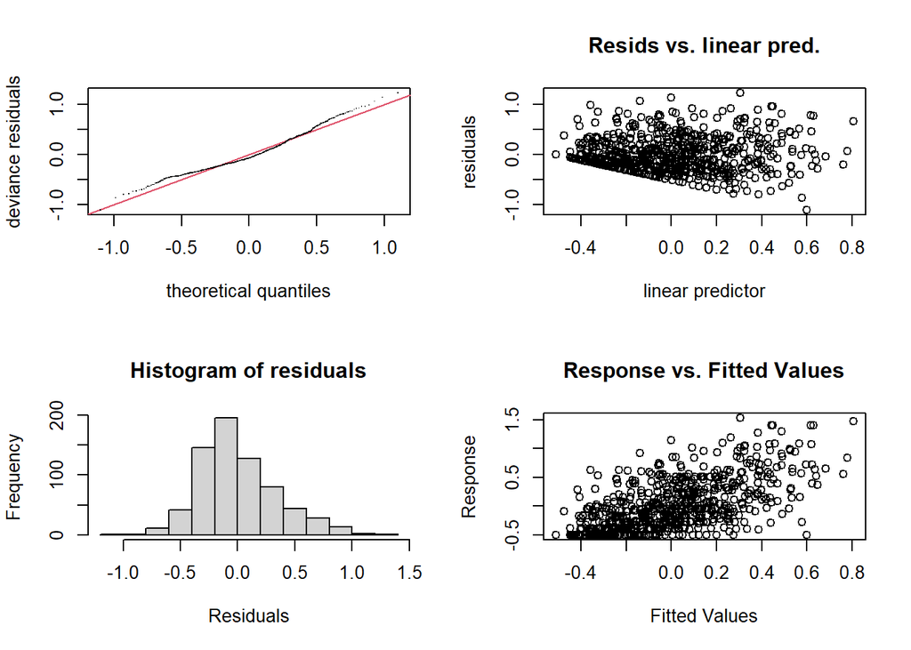

```
Method: REML   Optimizer: outer newton
full convergence after 6 iterations.
Gradient range [-1.324364e-05,8.12057e-08]
(score 282.261 & scale 0.1194046).
Hessian positive definite, eigenvalue range [0.2055039,342.5341].
Model rank =  24 / 24

Basis dimension (k) checking results. Low p-value (k-index<1) may
indicate that k is too low, especially if edf is close to k'.

                  k'  edf k-index p-value
s(SelfEfficacy) 7.00 5.98    0.94    0.03 *
s(Technology)   5.00 2.37    0.94    0.03 *
s(coach)        4.00 2.24    1.00    0.48
---
Signif. codes:  0 '***' 0.001 '**' 0.01 '*' 0.05 '.' 0.1 ' ' 1
```

```r
# --- 1. building generalized additive model (GAM) ---
# gam() (Generalized Additive Models) is specifically designed to capture non-linear relationships between
# predictors and the response using a data-driven approach (smooth terms), rather than forcing the user
# to pre-specify the shape of the relationship (like a straight line or a parabola).
gam.m1 <- gam(MLA ~ #sex +
                    # race +
                    class +
                    #math.level +
                    s(SelfEfficacy, bs = "cs", k = 8) +
                             s(Technology, bs = "cs", k = 6) +
                             #s(authority, bs = "cs", k = 7) +
                             #authority +
                             s(coach, bs = "cs", k = 5) +
                             facilitator +
                             #delegator +
                             Resource +
                             ISE,
                             #ABE ,
                             #s(ISE, bs = "cs", k = 4) +
                             #(ABE, bs = "cs", k = 4) +
                             #s(facilitator, bs = "cs", k = 7) +
                             #s(delegator, bs = "cs", k = 7),
                             #s(Resource, bs = "cs", k = 8),
              data = reg.data,
              select = TRUE,      # Enable automatic term selection
              method = "REML")    # Use REML for smoothness selection
# --- 2. Run the essential diagnostic check ---
# This is CRITICAL. Look at the "Basis dimension (k) checking results" section.
# If p < .05 for any term, increase k for that term.
gam.check(gam.m1)
```

```r
# --- 3. output ---
## summary of the gsm model
sum.gam.m1 <- summary(gam.m1)
sum.gam.m1
```

```
Family: gaussian
Link function: identity

Formula:
MLA ~ class + s(SelfEfficacy, bs = "cs", k = 8) + s(Technology,
    bs = "cs", k = 6) + s(coach, bs = "cs", k = 5) + facilitator +
    Resource + ISE

Parametric coefficients:
             Estimate Std. Error t value Pr(>|t|)
(Intercept) -0.003816   0.019562  -0.195  0.84538
classyr2    -0.035106   0.032483  -1.081  0.28020
classyr3     0.035808   0.036738   0.975  0.33007
classyr4     0.197853   0.078939   2.506  0.01243 *
classyr5+   -0.022282   0.056544  -0.394  0.69366
facilitator -0.102165   0.035190  -2.903  0.00381 **
Resource     0.109588   0.037072   2.956  0.00322 **
ISE         -0.039877   0.022829  -1.747  0.08113 .
---
Signif. codes:  0 '***' 0.001 '**' 0.01 '*' 0.05 '.' 0.1 ' ' 1

Approximate significance of smooth terms:
                  edf Ref.df      F p-value
s(SelfEfficacy) 5.981      7 17.437  <2e-16 ***
s(Technology)   2.374      5 10.031  <2e-16 ***
s(coach)        2.242      4  1.714  0.0295 *
---
Signif. codes:  0 '***' 0.001 '**' 0.01 '*' 0.05 '.' 0.1 ' ' 1

R-sq.(adj) =  0.359   Deviance explained = 37.5%
-REML = 282.26  Scale est. = 0.1194    n = 693
```

```r
sum.gam.m1 <-summary(gam.m1)
sum.gam.m1
```

```
Family: gaussian
Link function: identity

Formula:
MLA ~ class + s(SelfEfficacy, bs = "cs", k = 8) + s(Technology,
    bs = "cs", k = 6) + s(coach, bs = "cs", k = 5) + facilitator +
    Resource + ISE

Parametric coefficients:
             Estimate Std. Error t value Pr(>|t|)
(Intercept) -0.003816   0.019562  -0.195  0.84538
classyr2    -0.035106   0.032483  -1.081  0.28020
classyr3     0.035808   0.036738   0.975  0.33007
classyr4     0.197853   0.078939   2.506  0.01243 *
classyr5+   -0.022282   0.056544  -0.394  0.69366
facilitator -0.102165   0.035190  -2.903  0.00381 **
Resource     0.109588   0.037072   2.956  0.00322 **
ISE         -0.039877   0.022829  -1.747  0.08113 .
---
Signif. codes:  0 '***' 0.001 '**' 0.01 '*' 0.05 '.' 0.1 ' ' 1

Approximate significance of smooth terms:
                  edf Ref.df      F p-value
s(SelfEfficacy) 5.981      7 17.437  <2e-16 ***
s(Technology)   2.374      5 10.031  <2e-16 ***
s(coach)        2.242      4  1.714  0.0295 *
---
Signif. codes:  0 '***' 0.001 '**' 0.01 '*' 0.05 '.' 0.1 ' ' 1

R-sq.(adj) =  0.359   Deviance explained = 37.5%
-REML = 282.26  Scale est. = 0.1194    n = 693
```

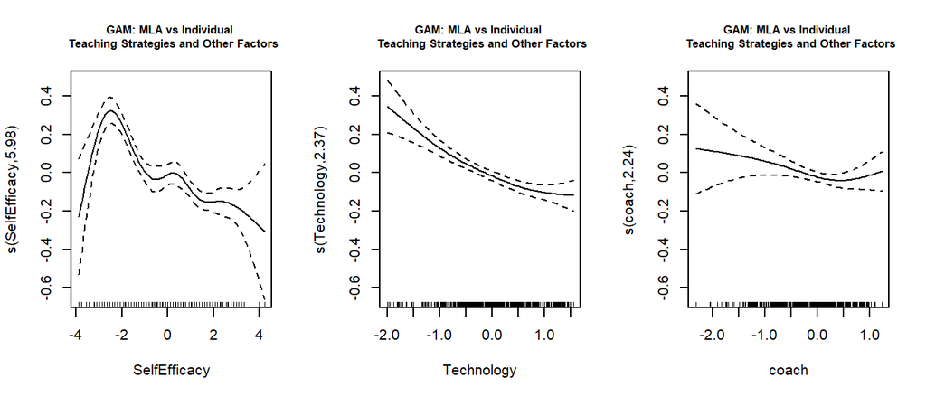

```r
# --- 4. Plot the smooth terms ---
# Use pages = 1 to see all plots on one page if you have a large screen,
# or pages = 2 to spread them across two pages.
par(mfrow = c(1,3))
plot(gam.m1,  main = "GAM: MLA vs Individual \n Teaching Strategies and Other Factors",
     cex.main = 0.8)
```

```r
#plot(gam.m1,  main = "GAM: MLA vs Individual \n Teaching Strategies and Other Factors",
#     cex.main = 0.8)
```

```r
# --- 5. Check for concurvity (collinearity in GAMs) ---
# High concurvity can make estimates unstable. Values > 0.8 are concerning.
concurvity(gam.m1, full = TRUE)
```

```
              para s(SelfEfficacy) s(Technology)  s(coach)
worst    0.5510885      0.16448183    0.09697167 0.7536148
observed 0.5510885      0.14890966    0.04631381 0.4324647
estimate 0.5510885      0.05875343    0.04497794 0.2723097
```

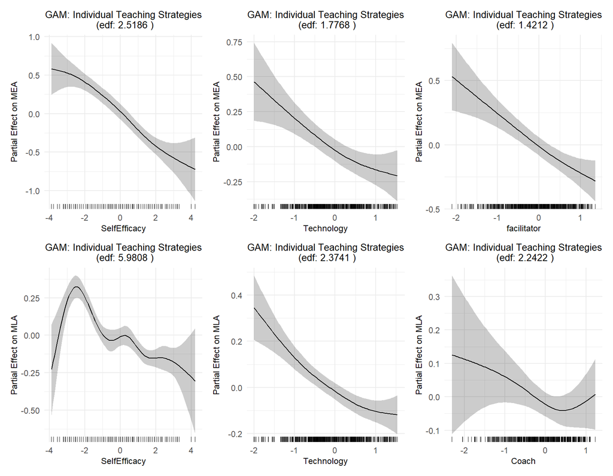

```r
# Build the 5 panels
p1 <- draw(gam.m0, select = "s(SelfEfficacy)",
           #residuals = TRUE,
           rug = TRUE,
           caption = FALSE,
           shade = TRUE) +
  labs(title = paste("GAM: Individual Teaching Strategies\n (edf:",round(sum.gam.m0$edf[1],4),")"), x = "SelfEfficacy", y = "Partial Effect on MEA") +
  theme_minimal(base_size = 11) +
  theme(legend.position = "none",
        plot.title = element_text(size = 10, hjust = 0.5),
        axis.title = element_text(size = 9))


p2 <- draw(gam.m0, select = "s(Technology)",
           #residuals = TRUE,
           rug = TRUE,
           caption = FALSE,
           shade = TRUE) +
  labs(title = paste("GAM: Individual Teaching Strategies\n (edf:",round(sum.gam.m0$edf[2],4),")"), x = "Technology", y = "Partial Effect on MEA") +
  theme_minimal(base_size = 11) +
  theme(legend.position = "none",
        plot.title = element_text(size = 10, hjust = 0.5),
        axis.title = element_text(size = 9))


p3 <- draw(gam.m0, select = "s(facilitator)",
           #residuals = TRUE,
           rug = TRUE,
           caption = FALSE,
           shade = TRUE) +
  labs(title = paste("GAM: Individual Teaching Strategies\n (edf:",round(sum.gam.m0$edf[3],4),")"), x = "facilitator", y = "Partial Effect on MEA") +
  theme_minimal(base_size = 11) +
  theme(legend.position = "none",
        plot.title = element_text(size = 10, hjust = 0.5),
        axis.title = element_text(size = 9))


p4 <- draw(gam.m1, select = "s(SelfEfficacy)",
           #residuals = TRUE,
           rug = TRUE,
           caption = FALSE,
           shade = TRUE) +
  labs(title = paste("GAM: Individual Teaching Strategies\n (edf:",round(sum.gam.m1$edf[1],4),")"), x = "SelfEfficacy", y = "Partial Effect on MLA") +
  theme_minimal(base_size = 11) +
  theme(legend.position = "none",
        plot.title = element_text(size = 10, hjust = 0.5),
        axis.title = element_text(size = 9))


p5 <- draw(gam.m1, select = "s(Technology)",
           # residuals = TRUE,
           rug = TRUE,
           caption = FALSE,
           shade = TRUE) +
  labs(title = paste("GAM: Individual Teaching Strategies\n (edf:",round(sum.gam.m1$edf[2],4),")"), x = "Technology", y = "Partial Effect on MLA") +
  theme_minimal(base_size = 11) +
  theme(legend.position = "none",
        plot.title = element_text(size = 10, hjust = 0.5),
        axis.title = element_text(size = 9))


p6 <- draw(gam.m1, select = "s(coach)",
           #residuals = TRUE,
           rug = TRUE,
           caption = FALSE,
           shade = TRUE) +
  labs(title = paste("GAM: Individual Teaching Strategies\n (edf:",round(sum.gam.m1$edf[3],4),")"), x = "Coach", y = "Partial Effect on MLA") +
  theme_minimal(base_size = 11) +
  theme(legend.position = "none",
        plot.title = element_text(size = 10, hjust = 0.5),
        axis.title = element_text(size = 9))



# Combine into a 2x3 grid with an empty bottom-right slot
# 5 plots in a 2x3 grid (last cell empty)
final_plot <- wrap_plots( p1,  p2,  p3,  p4,  p5, p6,
                         nrow = 2, ncol = 3)# +
  #plot_annotation(tag_levels = "A")

print(final_plot)
```

```r
pander(lm.boot.table(stepwise.mla.ind , 10000))
```

[output not shown]

## 11.2 Linear Regression Using Grouped Teaching Strategies

- **Regression of MEA with Grouped Teaching Strategies - Left Panel of Table 4**

The following residual diagnostic plots indicate abnormal patterns. Particular, non-constant variance of the residual variance.

```r
#mea.data.ctrd <- na.omit(reg.data[,-c(1, 3, 12:18)])
# The final model
#mla.best.subsets.ctrd <- regsubsets(MEA ~., data = mea.lm.data, nvmax = 16,  method = "backward" )
MEA.ctrd.all <- lm(MEA~ sex + race + class + major + math.level + modality + SelfEfficacy + Technology +
                     teacherCtrd + studentCtrd + ABE +  ISE + Resource, data = reg.data )
MEA.ctrd.step <- stepAIC(MEA.ctrd.all, direction = "both", trace = 0)
#
#kable(summary(MEA.ctrd.all)$coef, caption = "Table 3. Tentative model with all predictor variables: Imfluence of integrated (grouped) teaching strategies on MEA")
#pander(summary(MEA.ctrd.step)$coef, caption = "Table 4 (left panel). Association between math evaluation anxiety and perceived integrated (grouped) teaching strategies adjusted by demographics and environmental factors")
#
#kable(summary(MEA.ctrd.all)$coef)
summary(MEA.ctrd.step)
```

```
Call:
lm(formula = MEA ~ sex + class + math.level + SelfEfficacy +
    Technology + studentCtrd + ABE + ISE, data = reg.data)

Residuals:
     Min       1Q   Median       3Q      Max
-2.76292 -0.50560  0.02921  0.56710  2.15449

Coefficients:
                  Estimate Std. Error t value Pr(>|t|)
(Intercept)      -0.002436   0.096796  -0.025 0.979928
sexmale          -0.355592   0.073089  -4.865 1.42e-06 ***
classyr2          0.056132   0.078411   0.716 0.474320
classyr3          0.190033   0.094815   2.004 0.045440 *
classyr4          0.484272   0.194590   2.489 0.013061 *
classyr5+         0.183789   0.140842   1.305 0.192361
math.levelmath02  0.115581   0.114300   1.011 0.312276
math.levelmath03  0.223528   0.123794   1.806 0.071417 .
math.levelmath04  0.148280   0.148295   1.000 0.317719
math.levelother  -0.245181   0.153896  -1.593 0.111590
math.levelstats  -0.121227   0.116752  -1.038 0.299489
SelfEfficacy     -0.197799   0.019525 -10.130  < 2e-16 ***
Technology       -0.228089   0.042683  -5.344 1.25e-07 ***
studentCtrd      -0.168238   0.040735  -4.130 4.08e-05 ***
ABE               0.273506   0.075806   3.608 0.000331 ***
ISE              -0.100145   0.055135  -1.816 0.069758 .
---
Signif. codes:  0 '***' 0.001 '**' 0.01 '*' 0.05 '.' 0.1 ' ' 1

Residual standard error: 0.8261 on 677 degrees of freedom
Multiple R-squared:  0.3102,    Adjusted R-squared:  0.2949
F-statistic:  20.3 on 15 and 677 DF,  p-value: < 2.2e-16
```

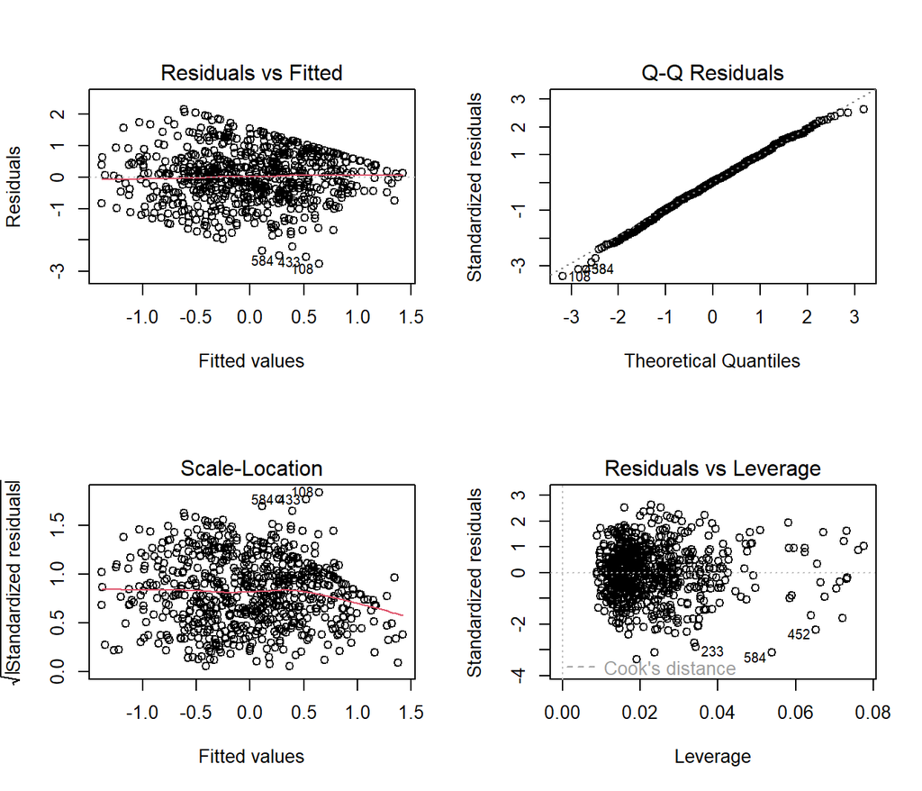

```r
par(mfrow = c(2,2))
plot(MEA.ctrd.step )
```

```r
summary(MEA.ctrd.all)
```

```
Call:
lm(formula = MEA ~ sex + race + class + major + math.level +
    modality + SelfEfficacy + Technology + teacherCtrd + studentCtrd +
    ABE + ISE + Resource, data = reg.data)

Residuals:
     Min       1Q   Median       3Q      Max
-2.73592 -0.53054  0.02522  0.55588  2.12963

Coefficients:
                     Estimate Std. Error t value Pr(>|t|)
(Intercept)         -0.137252   0.203449  -0.675 0.500148
sexmale             -0.358881   0.074467  -4.819 1.79e-06 ***
raceBlack            0.319826   0.180873   1.768 0.077479 .
raceother            0.167865   0.180859   0.928 0.353666
racewhite            0.100605   0.147412   0.682 0.495176
classyr2             0.053466   0.079744   0.670 0.502791
classyr3             0.168781   0.096587   1.747 0.081019 .
classyr4             0.455257   0.204653   2.225 0.026447 *
classyr5+            0.204923   0.144602   1.417 0.156905
majorHealth         -0.059605   0.139990  -0.426 0.670405
majorOther          -0.007583   0.110439  -0.069 0.945277
majorSTEM           -0.047525   0.094222  -0.504 0.614150
math.levelmath02     0.123280   0.122429   1.007 0.314326
math.levelmath03     0.232673   0.141517   1.644 0.100618
math.levelmath04     0.171604   0.156358   1.098 0.272816
math.levelother     -0.229789   0.161743  -1.421 0.155869
math.levelstats     -0.095505   0.136847  -0.698 0.485483
modalityKinesthetic  0.045423   0.086081   0.528 0.597903
modalityVisual       0.046882   0.088239   0.531 0.595382
SelfEfficacy        -0.187961   0.020276  -9.270  < 2e-16 ***
Technology          -0.223783   0.044340  -5.047 5.79e-07 ***
teacherCtrd         -0.080167   0.088462  -0.906 0.365136
studentCtrd         -0.112565   0.073152  -1.539 0.124328
ABE                  0.294096   0.078095   3.766 0.000181 ***
ISE                 -0.114019   0.058170  -1.960 0.050401 .
Resource             0.065304   0.093077   0.702 0.483171
---
Signif. codes:  0 '***' 0.001 '**' 0.01 '*' 0.05 '.' 0.1 ' ' 1

Residual standard error: 0.8282 on 667 degrees of freedom
Multiple R-squared:  0.317, Adjusted R-squared:  0.2914
F-statistic: 12.38 on 25 and 667 DF,  p-value: < 2.2e-16
```

The results above are consistent with the previous regression that used individual teaching strategies as predictors. The key difference is that the **integrative teaching approach** was significant in the former model, whereas **student-centered** teaching strategies are significant in the current one. However, since an integrative approach is a specific type of student-centered strategy, the models ultimately yield congruent findings.

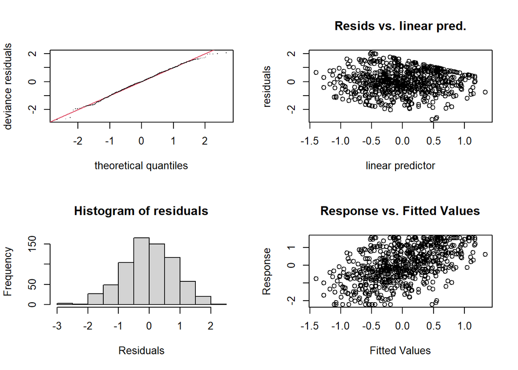

```
Method: REML   Optimizer: outer newton
full convergence after 6 iterations.
Gradient range [-9.760532e-08,8.769733e-08]
(score 875.335 & scale 0.6991171).
Hessian positive definite, eigenvalue range [0.6708458,342.5071].
Model rank =  18 / 18

Basis dimension (k) checking results. Low p-value (k-index<1) may
indicate that k is too low, especially if edf is close to k'.

                  k'  edf k-index p-value
s(SelfEfficacy) 3.00 2.02    0.97    0.22
s(Technology)   3.00 1.78    0.90  <2e-16 ***
s(teacherCtrd)  4.00 1.56    0.97    0.20
---
Signif. codes:  0 '***' 0.001 '**' 0.01 '*' 0.05 '.' 0.1 ' ' 1
```

```r
gam.m2 <- gam(MEA ~ sex +
                class +
                #math.level +
                #race +
                s(SelfEfficacy, bs = "cs", k = 4) +
                s(Technology, bs = "cs", k = 4) +
                s(teacherCtrd, bs = "cs", k=5) +
                ISE +
                ABE,
                #(ISE, bs = "cs", k = 5) +
                #s(ABE, bs = "cs", k = 5),
                #StudentCtrd  +
                #s(Resource, bs = "cs", k = 4) +
                #Engage,
              data = reg.data,
              select = TRUE,      # Enable automatic term selection
              method = "REML")    # Use REML for smoothness selection
gam.check(gam.m2)
```

```r
# ---  Check for concurvity (collinearity in GAMs) ---
# High concurvity can make estimates unstable. Values > 0.8 are concerning.
concurvity(gam.m2, full = TRUE)
```

```
              para s(SelfEfficacy) s(Technology) s(teacherCtrd)
worst    0.6322726       0.1369408    0.13049047     0.14649225
observed 0.6322726       0.1337829    0.08831702     0.13951374
estimate 0.6322726       0.1152384    0.06166668     0.07177738
```

```r
sum.gam.m2 <- summary(gam.m2)
sum.gam.m2
```

```
Family: gaussian
Link function: identity

Formula:
MEA ~ sex + class + s(SelfEfficacy, bs = "cs", k = 4) + s(Technology,
    bs = "cs", k = 4) + s(teacherCtrd, bs = "cs", k = 5) + ISE +
    ABE

Parametric coefficients:
            Estimate Std. Error t value Pr(>|t|)
(Intercept)  0.04563    0.05222   0.874   0.3826
sexmale     -0.30375    0.07226  -4.204 2.98e-05 ***
classyr2     0.05253    0.07820   0.672   0.5020
classyr3     0.10291    0.08832   1.165   0.2444
classyr4     0.36478    0.19049   1.915   0.0559 .
classyr5+    0.11765    0.13652   0.862   0.3891
ISE         -0.13402    0.05458  -2.456   0.0143 *
ABE          0.30813    0.07659   4.023 6.39e-05 ***
---
Signif. codes:  0 '***' 0.001 '**' 0.01 '*' 0.05 '.' 0.1 ' ' 1

Approximate significance of smooth terms:
                  edf Ref.df      F  p-value
s(SelfEfficacy) 2.017      3 32.369  < 2e-16 ***
s(Technology)   1.777      3  7.422 3.95e-06 ***
s(teacherCtrd)  1.556      4  4.966 7.69e-06 ***
---
Signif. codes:  0 '***' 0.001 '**' 0.01 '*' 0.05 '.' 0.1 ' ' 1

R-sq.(adj) =  0.278   Deviance explained = 29.1%
-REML = 875.34  Scale est. = 0.69912   n = 693
```

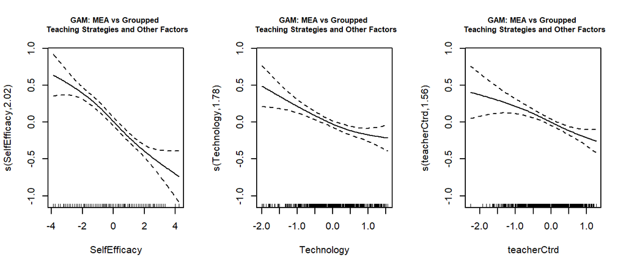

```r
par(mfrow= c(1,3))
plot(gam.m2, main = "GAM: MEA vs Groupped \n Teaching Strategies and Other Factors",
     cex.main = 0.8)
```

```r
# --- 5. Check for concurvity (collinearity in GAMs) ---
# High concurvity can make estimates unstable. Values > 0.8 are concerning.
concurvity(gam.m2, full = TRUE)
```

```
              para s(SelfEfficacy) s(Technology) s(teacherCtrd)
worst    0.6322726       0.1369408    0.13049047     0.14649225
observed 0.6322726       0.1337829    0.08831702     0.13951374
estimate 0.6322726       0.1152384    0.06166668     0.07177738
```

- **Regression of MLA with Grouped Teaching Strategies - Right Panel of Table 4**

```r
# The final model
#mla.best.subsets.ctrd <- regsubsets(MEA ~., data = mea.lm.data, nvmax = 16,  method = "backward" )
MLA.ctrd.all <- lm(MLA~ sex + race + class + major + math.level + modality + SelfEfficacy + Technology +
                     teacherCtrd + studentCtrd + ABE +  ISE + Resource, data = reg.data )
MLA.ctrd.step <- stepAIC(MLA.ctrd.all, direction = "both", trace = 0)
#
#kable(summary(MEA.ctrd.all)$coef, caption = "Table 3. Tentative model with all predictor variables: Imfluence of integrated (grouped) teaching strategies on MEA")
#pander(summary(MEA.ctrd.step)$coef, caption = "Table 4 (left panel). Association between math learninganxiety and perceived integrated (grouped) teaching strategies adjusted by demographics and environmental factors")
#
summary(MLA.ctrd.step)
```

```
Call:
lm(formula = MLA ~ race + SelfEfficacy + Technology + teacherCtrd +
    ISE + Resource, data = reg.data)

Residuals:
     Min       1Q   Median       3Q      Max
-0.94369 -0.24634 -0.05662  0.21094  1.26411

Coefficients:
              Estimate Std. Error t value Pr(>|t|)
(Intercept)  -0.013434   0.059509  -0.226   0.8215
raceBlack     0.163467   0.076590   2.134   0.0332 *
raceother     0.015814   0.075869   0.208   0.8350
racewhite    -0.002243   0.061470  -0.036   0.9709
SelfEfficacy -0.081884   0.008425  -9.720  < 2e-16 ***
Technology   -0.122169   0.017820  -6.856 1.59e-11 ***
teacherCtrd  -0.147805   0.021058  -7.019 5.40e-12 ***
ISE          -0.033479   0.023156  -1.446   0.1487
Resource      0.093472   0.037939   2.464   0.0140 *
---
Signif. codes:  0 '***' 0.001 '**' 0.01 '*' 0.05 '.' 0.1 ' ' 1

Residual standard error: 0.3555 on 684 degrees of freedom
Multiple R-squared:  0.3289,    Adjusted R-squared:  0.3211
F-statistic: 41.91 on 8 and 684 DF,  p-value: < 2.2e-16
```

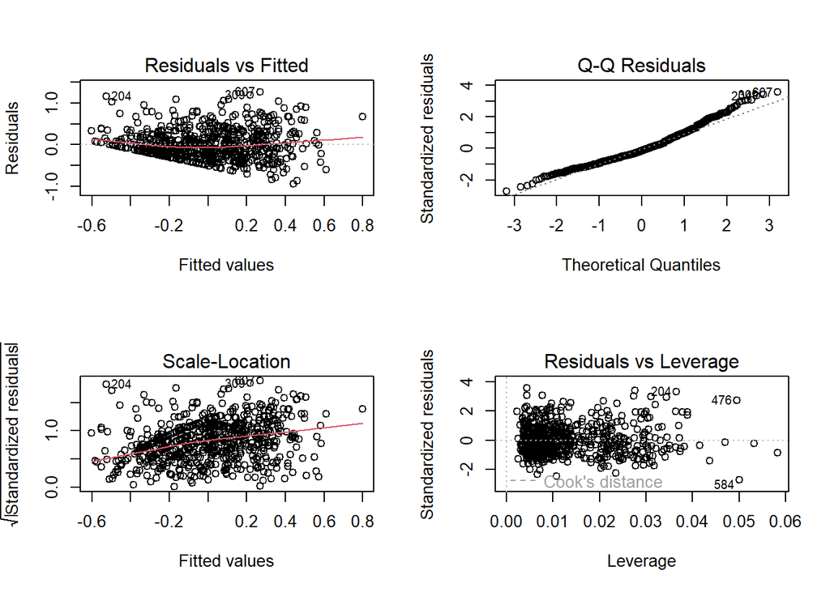

```r
#kable(summary(MEA.ctrd.all)$coef)
par(mfrow = c(2,2))
plot(MLA.ctrd.step )
```

```r
summary(MLA.ctrd.step)
```

```
Call:
lm(formula = MLA ~ race + SelfEfficacy + Technology + teacherCtrd +
    ISE + Resource, data = reg.data)

Residuals:
     Min       1Q   Median       3Q      Max
-0.94369 -0.24634 -0.05662  0.21094  1.26411

Coefficients:
              Estimate Std. Error t value Pr(>|t|)
(Intercept)  -0.013434   0.059509  -0.226   0.8215
raceBlack     0.163467   0.076590   2.134   0.0332 *
raceother     0.015814   0.075869   0.208   0.8350
racewhite    -0.002243   0.061470  -0.036   0.9709
SelfEfficacy -0.081884   0.008425  -9.720  < 2e-16 ***
Technology   -0.122169   0.017820  -6.856 1.59e-11 ***
teacherCtrd  -0.147805   0.021058  -7.019 5.40e-12 ***
ISE          -0.033479   0.023156  -1.446   0.1487
Resource      0.093472   0.037939   2.464   0.0140 *
---
Signif. codes:  0 '***' 0.001 '**' 0.01 '*' 0.05 '.' 0.1 ' ' 1

Residual standard error: 0.3555 on 684 degrees of freedom
Multiple R-squared:  0.3289,    Adjusted R-squared:  0.3211
F-statistic: 41.91 on 8 and 684 DF,  p-value: < 2.2e-16
```

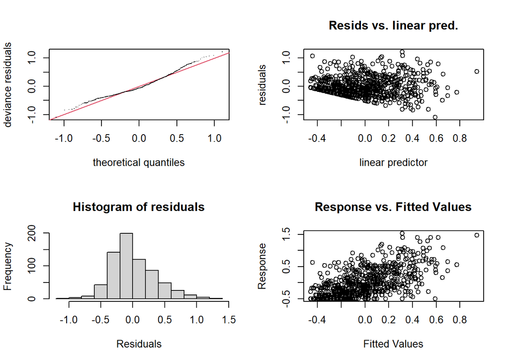

```
Method: REML   Optimizer: outer newton
full convergence after 6 iterations.
Gradient range [-1.184105e-08,5.64909e-09]
(score 277.4271 & scale 0.1203305).
Hessian positive definite, eigenvalue range [0.7589382,344.0329].
Model rank =  20 / 20

Basis dimension (k) checking results. Low p-value (k-index<1) may
indicate that k is too low, especially if edf is close to k'.

                  k'  edf k-index p-value
s(SelfEfficacy) 7.00 5.96    0.94    0.09 .
s(Technology)   5.00 2.25    0.93    0.04 *
s(teacherCtrd)  3.00 2.12    0.96    0.16
---
Signif. codes:  0 '***' 0.001 '**' 0.01 '*' 0.05 '.' 0.1 ' ' 1
```

```r
gam.m3 <- gam(MLA ~  race +
                     #sex +
                     s(SelfEfficacy, bs = "cs", k =8) +
                     s(Technology, bs = "cs", k = 6) +
                     s(teacherCtrd, bs = "cs", k = 4) +
                     Resource,# +
                     #s(StudentCtrd, bs = "cs", k = 4),# +
                     #s(Engage, bs = "cs", k = 4) ,
              data = reg.data,
              select = TRUE,      # Enable automatic term selection
              method = "REML")    # Use REML for smoothness selection
##
gam.check(gam.m3)
```

```r
# --- 5. Check for concurvity (collinearity in GAMs) ---
# High concurvity can make estimates unstable. Values > 0.8 are concerning.
concurvity(gam.m3, full = TRUE)
```

```
              para s(SelfEfficacy) s(Technology) s(teacherCtrd)
worst    0.9494393       0.1319500    0.10267228      0.1183954
observed 0.9494393       0.1272535    0.04958552      0.1167236
estimate 0.9494393       0.0476207    0.04331952      0.1005645
```

```r
sum.gam.m3 <- summary(gam.m3)
sum.gam.m3
```

```
Family: gaussian
Link function: identity

Formula:
MLA ~ race + s(SelfEfficacy, bs = "cs", k = 8) + s(Technology,
    bs = "cs", k = 6) + s(teacherCtrd, bs = "cs", k = 4) + Resource

Parametric coefficients:
             Estimate Std. Error t value Pr(>|t|)
(Intercept) -0.015794   0.058412  -0.270   0.7869
raceBlack    0.143567   0.075154   1.910   0.0565 .
raceother    0.015209   0.074395   0.204   0.8381
racewhite    0.001748   0.060362   0.029   0.9769
Resource     0.074474   0.035870   2.076   0.0383 *
---
Signif. codes:  0 '***' 0.001 '**' 0.01 '*' 0.05 '.' 0.1 ' ' 1

Approximate significance of smooth terms:
                  edf Ref.df     F p-value
s(SelfEfficacy) 5.956      7 18.45  <2e-16 ***
s(Technology)   2.254      5 10.01  <2e-16 ***
s(teacherCtrd)  2.118      3 18.59  <2e-16 ***
---
Signif. codes:  0 '***' 0.001 '**' 0.01 '*' 0.05 '.' 0.1 ' ' 1

R-sq.(adj) =  0.354   Deviance explained = 36.7%
-REML = 277.43  Scale est. = 0.12033   n = 693
```

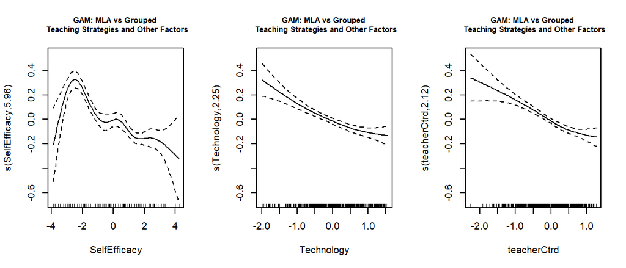

```r
par(mfrow = c(1,3))
plot(gam.m3, main = "GAM: MLA vs Grouped \n Teaching Strategies and Other Factors",
     cex.main = 0.8)
```

```r
# --- 5. Check for concurvity (collinearity in GAMs) ---
# High concurvity can make estimates unstable. Values > 0.8 are concerning.
concurvity(gam.m3, full = TRUE)
```

```
              para s(SelfEfficacy) s(Technology) s(teacherCtrd)
worst    0.9494393       0.1319500    0.10267228      0.1183954
observed 0.9494393       0.1272535    0.04958552      0.1167236
estimate 0.9494393       0.0476207    0.04331952      0.1005645
```

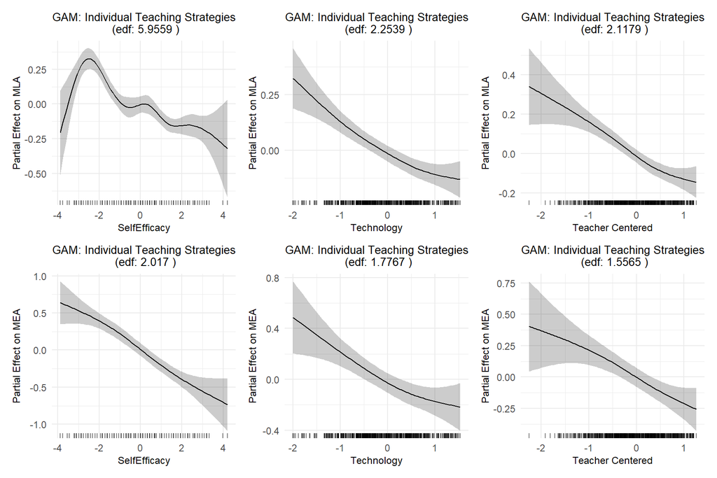

```r
# Build the 5 panels
q1 <- draw(gam.m3, select = "s(SelfEfficacy)",
           #residuals = TRUE,
           rug = TRUE,
           caption = FALSE,
           shade = TRUE) +
  #ylim(-0.2, 0.5) +
  labs(title = paste("GAM: Individual Teaching Strategies\n (edf:",round(sum.gam.m3$edf[1],4),")"), x = "SelfEfficacy", y = "Partial Effect on MLA") +
  theme_minimal(base_size = 11) +
  theme(legend.position = "none",
        plot.title = element_text(size = 10, hjust = 0.5),
        axis.title = element_text(size = 9))


q2 <- draw(gam.m3, select = "s(Technology)",
           #residuals = TRUE,
           rug = TRUE,
           caption = FALSE,
           shade = TRUE) +
  #ylim(-0.2, 0.5) +
  labs(title = paste("GAM: Individual Teaching Strategies\n (edf:",round(sum.gam.m3$edf[2],4),")"), x = "Technology", y = "Partial Effect on MLA") +
  theme_minimal(base_size = 11) +
  theme(legend.position = "none",
        plot.title = element_text(size = 10, hjust = 0.5),
        axis.title = element_text(size = 9))


q3 <- draw(gam.m3, select = "s(teacherCtrd)",
           #residuals = TRUE,
           rug = TRUE,
           caption = FALSE,
           shade = TRUE) +
  #ylim(-0.2, 0.5) +
  labs(title = paste("GAM: Individual Teaching Strategies\n (edf:",round(sum.gam.m3$edf[3],4),")"), x = "Teacher Centered", y = "Partial Effect on MLA") +
  theme_minimal(base_size = 11) +
  theme(legend.position = "none",
        plot.title = element_text(size = 10, hjust = 0.5),
        axis.title = element_text(size = 9))


q4 <- draw(gam.m2, select = "s(SelfEfficacy)",
           #residuals = TRUE,
           #rug = TRUE,
           caption = FALSE,
           shade = TRUE) +
  #ylim(-0.1, 1) +
  labs(title = paste("GAM: Individual Teaching Strategies\n (edf:",round(sum.gam.m2$edf[1],4),")"), x = "SelfEfficacy", y = "Partial Effect on MEA") +
  theme_minimal(base_size = 11) +
  theme(legend.position = "none",
        plot.title = element_text(size = 10, hjust = 0.5),
        axis.title = element_text(size = 9))


q5 <- draw(gam.m2, select = "s(Technology)",
           # residuals = TRUE,
           rug = TRUE,
           caption = FALSE,
           shade = TRUE) +
  #ylim(-0.1, 1) +
  labs(title = paste("GAM: Individual Teaching Strategies\n (edf:",round(sum.gam.m2$edf[2],4),")"), x = "Technology", y = "Partial Effect on MEA") +
  theme_minimal(base_size = 11) +
  theme(legend.position = "none",
        plot.title = element_text(size = 10, hjust = 0.5),
        axis.title = element_text(size = 9))


q6 <- draw(gam.m2, select = "s(teacherCtrd)",
           # residuals = TRUE,
           rug = TRUE,
           caption = FALSE,
           shade = TRUE) +
  #ylim(-0.1, 1) +
  labs(title = paste("GAM: Individual Teaching Strategies\n (edf:",round(sum.gam.m2$edf[3],4),")"), x = "Teacher Centered", y = "Partial Effect on MEA") +
  theme_minimal(base_size = 11) +
  theme(legend.position = "none",
        plot.title = element_text(size = 10, hjust = 0.5),
        axis.title = element_text(size = 9))
#
#
# Combine into a 2x3 grid with an empty bottom-right slot
# 5 plots in a 2x3 grid (last cell empty)
final_plot <- wrap_plots(q1, q2, q3, q4, q5, q6,
                         nrow = 2, ncol = 3)# +
  #plot_annotation(tag_levels = "A")

print(final_plot)
```

# 12 References

Ashcraft, M. H. (2002). Math anxiety: Personal, educational, and cognitive consequences. Current directions in psychological science, 11(5), 181-185.

Ashcraft, M. H., & Krause, J. A. (2007). “Working memory, math performance, and math anxiety.” Psychonomic Bulletin & Review, 14(2), 243-248.

Asparouhov, T., & Muthén, B. (2005, November). Multivariate statistical modeling with survey data. In Proceedings of the Federal Committee on Statistical Methodology (FCSM) research conference (pp. 14-16).

Bandalos, D. L. (2018). Measurement theory and applications for the social sciences. Guilford Publications.

Bandura, A. (1997). Self-efficacy: The exercise of control (Vol. 11). Freeman.

Boaler, J. (2015). Mathematical mindsets: Unleashing students’ potential through creative math, inspiring messages and innovative teaching. John Wiley & Sons.

Borich, G. D. (2017). Effective Teaching Methods: Research-Based Practice (9th ed.). Pearson.

Brown, H. D., & Lee, H. (1994). Teaching by principles: An interactive approach to language pedagogy (Vol. 1, p. 994). Englewood Cliffs, NJ: Prentice Hall Regents.

Brown, T. A. (2015). Confirmatory factor analysis for applied research. Guilford publications.

Bruner, J. S. (1961). The act of discovery. Harvard educational review. Cattell, R. B. (1952). Factor analysis: an introduction and manual for the psychologist and social scientist.

Chang, H., & Beilock, S. L. (2016). The math anxiety-math performance link and its relation to individual and environmental factors: A review of current behavioral and psychophysiological research. Current Opinion in Behavioral Sciences, 10, 33–38.

Cronbach, L. J. (1951). Coefficient alpha and the internal structure of tests. Biometrika, 16, 297–335.

Daker, R. J., Gattas, S. U., Sokolowski, H. M., Green, A. E., & Lyons, I. M. (2021). First-year students’ math anxiety predicts STEM avoidance and underperformance throughout university, independently of math ability. Npj Science of Learning, 6(1), 17.

Devine, A., Fawcett, K., Szűcs, D., & Dowker, A. (2012). Gender differences in mathematics anxiety and the relation to mathematics performance while controlling for test anxiety. Behavioral and brain functions, 8(1), 33.

DiStefano, C., Zhu, M., & Mindrila, D. (2009). Understanding and using factor scores: Considerations for the applied researcher. Practical assessment, research, and evaluation, 14(1).

Dreger, R. M., & Aiken Jr, L. R. (1957). The identification of number anxiety in a college population. Journal of Educational Psychology, 48(6), 344.

Duncan, O. D. (1961). A socioeconomic index for all occupations. Occupations and social status..

Dweck, C. S. (2006). Mindset: The new psychology of success. Random house.

Else-Quest, N. M., Hyde, J. S., & Linn, M. C. (2010). Cross-national patterns of gender differences in mathematics: a meta-analysis. Psychological bulletin, 136(1), 103.

Finney, S. J., & DiStefano, C. (2006). Non-normal and categorical data in structural equation modeling. Structural equation modeling: A second course, 10(6), 269-314.

Flora, D. B. (2017). Statistical Methods for the Social and Behavioural Sciences: A Model-Based Approach. SAGE.

Fogarty, R. (1991). The mindful school: How to integrate the curricula. Palatine, IL. SkyLight Publishing, Inc. Retrieved February, 22, 2002.

Gierl, M. J., & Bisanz, J. (1995). Anxieties and attitudes related to mathematics in grades 3 and 6. The Journal of experimental education, 63(2), 139-158.

Goetz, T., Bieg, M., Lüdtke, O., Pekrun, R., & Hall, N. C. (2013). Do girls really experience more anxiety in mathematics?. Psychological science, 24(10), 2079-2087.

Gough, Mary O. (1954). Why failures in mathematics? Mathemaphobia: Causes and treatments. The Clearing House: A Journal of Educational Strategies, Issues and Ideas, 28(5), 290–294.

Guttman, L. (1954). Some necessary conditions for common-factor analysis. Psychometrika, 19(2), 149-161.

Hattie, J. (2012). Visible learning for teachers: Maximizing impact on learning. Routledge.

Hembree, R. (1990). The nature, effects, and relief of mathematics anxiety. Journal for research in mathematics education, 21(1), 33-46.

Hopko, D. R., Mahadevan, R., Bare, R. L., & Hunt, M. K. (2003). The abbreviated math anxiety scale (AMAS) construction, validity, and reliability. Assessment, 10(2), 178–182.

Hirschberg, E., & Standish, C. V. (1959). A method of deriving a stratification score by using the principal components of the correlation matrix. American Statistical Association, Proceedings of the Social Statistics Section, 1959, 220-225.

Jacobs, H. H. (1989). Interdisciplinary curriculum: Design and implementation. Association for Supervision and Curriculum Development, 1250 N. Pitt Street, Alexandria, VA 22314.

Jolliffe, I. T., & Cadima, J. (2016). Principal Component Analysis: A Review and Recent Developments. Philosophical Transactions of the Royal Society A, 374(2065), 20150202.

Johnson, D. W., Johnson, R. T., & Smith, K. A. (2014). Cooperative learning: Improving university instruction by basing practice on validated theory. Journal on excellence in college teaching, 25(3&4).

Jose M. Cardino Jr. and Ruth A. Ortega-Dela Cruz, Understanding of learning styles and teaching strategies towards improving the teaching and learning of mathematics, LUMAT General Issue, Vol 8 No 1 (2020), 19–43. Doi: 10.31129/ LUMAT.8.1.1348

Joyce, B., Weil, M., & Calhoun, E. (2015). Models of Teaching (9th ed.). Pearson.

Klee, H. L., Buehl, M. M., & Miller, A. D. (2022). Strategies for alleviating students’ math anxiety: Control-value theory in practice. Theory Into Practice, 61(1), 49–61.

Kline, R. B. (2023). Principles and practice of structural equation modeling. Guilford publications.

Lazarsfeld, P. F., Stouffer, S. A., Guttman, L., & Suchman, E. A. (1950). Measurement and prediction. SA Stouffer (éd.) Studies in social psychology in world war II, 4.

Li, C. H. (2016). The performance of ML, DWLS, and ULS estimation with robust corrections in structural equation models with ordinal variables. Psychological methods, 21(3), 369.

López-Bonilla, J. M.l and López-Bonilla, L. M. (2012), Validation of an information technology anxiety scale in undergraduates, British Journal of Educational Technology Vol 43. No 2. E56–E58. doi:10.1111/j.1467-8535.2011.01256.x

Luttenberger, S., Wimmer, S., & Paechter, M. (2018). Spotlight on math anxiety. Psychology research and behavior management, 311-322.

Maloney, E. A., & Beilock, S. L. (2012). Math anxiety: Who has it, why it develops, and how to guard against it. Trends in cognitive sciences, 16(8), 404-406.

Marsh, H. W. (1996). Positive and negative self-esteem: A substantively meaningful distinction or artifactors? Journal of Personality and Social Psychology, 70(4), 810–819.

McDonald, R. P. (1999). Test theory: A unified treatment. Mahwah: Erlbaum.

Moliner, L., & Alegre, F. (2020). Peer tutoring effects on students’ mathematics anxiety: A middle school experience. Frontiers in Psychology, 11, 1610.

Muthén, B. (1984). A general structural equation model with dichotomous, ordered categorical, and continuous latent variable indicators. Psychometrika, 49(1), 115-132.

O’Leary, K., Fitzpatrick, C. L., & Hallett, D. (2017). Math anxiety is related to some, but not all, experiences with math. Frontiers in Psychology, 8, 2067.

Ormrod, J. E. (2020). Human Learning (8th ed.). Pearson

Olsson, U. (1979). Maximum likelihood estimation of the polychoric correlation coefficient. Psychometrika, 44(4), 443-460.

Pletzer, B., Wood, G., Scherndl, T., Kerschbaum, H. H., & Nuerk, H.C. (2016). Components of mathematics anxiety: Factor modeling of the MARS30-brief. Frontiers in Psychology, 7, 91.

Prince, M. J., & Felder, R. M. (2006). Inductive teaching and learning methods: Definitions, comparisons, and research bases. Journal of engineering education, 95(2), 123-138.

Ramirez, G., Shaw, S. T., & Maloney, E. A. (2018). Math anxiety: Past research, promising interventions, and a new interpretation framework. Educational psychologist, 53(3), 145-164.

Richardson, F. C., & Suinn, R. M. (1972). The mathematics anxiety rating scale: Psychometric data. Journal of Counseling Psychology, 19(6), 551.

Rozgonjuk, D., Kraav, T., Mikkor, K., Orav-Puurand, K., & Täht, K. (2020). Mathematics anxiety among STEM and social science students: The roles of mathematics self-efficacy, and deep and surface approach to learning. International Journal of STEM Education, 7(1), 1–11.

Segool, N. K., Carlson, J. S., Goforth, A. N., Von Der Embse, N., & Barterian, J. A. (2013). Heightened test anxiety among young children: Elementary school students’ anxious responses to high-stakes testing. Psychology in the Schools, 50(5), 489–499.

Spooren, P., Brockx, B., & Mortelmans, D. (2013). On the validity of student evaluation of teaching: The state of the art. Review of Educational Research, 83(4), 598-642.

Watson, D., Clark, L. A., & Tellegen, A. (1988). Development and validation of brief measures of positive and negative affect: The PANAS scales. Journal of Personality and Social Psychology, 54(6), 1063–1070.

Wilson, S. (2013). Mature age pre-service teachers’ mathematics anxiety and factors impacting on university retention. Mathematics Education: Yesterday, Today and Tomorrow (MERGA36), 666–673.

Zakaria, E., Zain, N. M., Ahmad, N. A., & Erlina, A. (2012). Mathematics anxiety and achievement among secondary school students. American Journal of Applied Sciences, 9(11), 1828.

# 13 Appendix

## 13.1 Survey Instruments

### 13.1.1 Abbreviated Math Anxiety Scale (AMAS)

The Abbreviated Math Anxiety Scale (AMAS; Hopko et al., 2003) comprises nine items on two subscales: Math Learning Anxiety (MLA) and Math Evaluation Anxiety (MEA). Items are rated on a 5-point Likert scale from 1 (not at all anxious) to 5 (very anxious).

Please rate your feelings during different activities on a scale from 1 to 5. Try not to spend too much time on any one item. There are no right or wrong answers.

`1 = No bad feelings, 2 = Somewhat bad, 3 = nervous, 4 = Very bad feelings, 5 = Worst feelings`

1. Having to use tables in the back of a math book.
2. Thinking about a math test the day before you take it.
3. Watching the teacher work out a math problem on the board.
4. Taking a math test.
5. Being given a homework assignment of many difficult problems that is due for the next class meeting.
6. Listening to a lecture in math class. [Listening to the teacher talk for a long time in math]
7. Listening to another student explain how to do a math problem.
8. Being given a quiz on math without knowing in advance.
9. Starting a new chapter in a math book. [Starting a new topic in math]

### 13.1.2 Math Self-efficacy Scale

A three-item scale adapted from Rozgonjuk et al. (2020) measured situation-specific beliefs about mathematical ability

Select the response that matches how much you now agree with each statement. Try not to spend too much time on any one item. There are no right or wrong answers.

`1 = Strongly disagree 2 = disagree 3 = neutral 4 = agree 5 = Strongly agree`

1. I usually understand a mathematical idea quickly.
2. I have to work very hard to understand mathematics.
3. I can connect the mathematical ideas that I have learned.

### 13.1.3 Teaching Strategies Questionnaire

The following statements are the ways your teacher teaches mathematics. Respond to the items listed below:

`5 – Always, 4 – Often, 3 – Sometimes, 2 – Seldom, 1 – Never`

**Authority (Lecture)**

1. The teacher uses direct presentation to provide students with information.
2. The teacher begins by presenting the main ideas of the topic at the beginning of the class.
3. The teacher moves from the abstract to the concrete examples.
4. Teachers’ cognitive teaching strategies harmonize with students’ learning strategies.
5. The teacher trains students to learn the whole concept before the specific idea.
6. The teacher uses specific questions to discuss the whole topic.
7. The teacher begins the teaching-learning situation by presenting a problem to students.

**Demonstrator (Coach)**

1. The teacher helps his students imitate desired models by showing them.
2. The teacher shows students how to verify information and facts before making judgments.
3. The teacher teaches students the way to identify those simple tricks to understand the lesson.
4. The teacher provides students with feedback regarding their answers at all times.
5. The teacher trains students on generating specific answers to the questions raised to them.
6. The teacher gives similar examples during the discussion to secure the mastery of the topic.
7. The teacher uses specific problem-solving strategies in the teaching process.

**Facilitator (Activity Approach)**

1. The teacher gives students enough time to think and to investigate with others to achieve a desirable result.
2. The teacher gives students a chance to generate new concepts.
3. The teacher allows students to have more clarifications and explanations on a certain topic.
4. The teacher trains students to solve their problems in a comfortable way.
5. The teacher provides students with a chance to apply new knowledge in new real-life situations.
6. Students tend to generate new information by making comparisons between their previous knowledge and the new information.
7. The teacher helps students to analyze the main idea to be used in discussing the topic as a whole.
8. The teacher facilitates students to make use of the procedures that organize memory potentials (symbolizing information).

**Delegator (Group Style)**

1. The teacher encourages students to work with others to generate as many alternatives as they can for the problem discussed.
2. The teacher applies group work in the class to serve desired objectives.
3. The teacher distributes different teaching-learning tasks to students.
4. The teacher lets students have their own conversations positively.
5. The teacher makes students take part in different roles.
6. The teacher asks students to do written or verbal summaries of the information they get.
7. The teacher assigns students a specific task within a general task.

### 13.1.4 Use of technologies Scale

Information Technologies Anxiety Scale (ITAS). This scale measures information technology anxiety in undergraduates (Lopez-Bonilla and Lopez-Bonilla, 2012).

`1: strongly disagree, 2: disagree, 3. Neutral, 4 agree, 5. Strongly agree`

1. I feel apprehensive about using information technologies (ITs)
2. Technological information sounds like confusing jargon to me
3. I have avoided ITs because it is unfamiliar to me
4. I hesitate to use ITs for fear of making mistakes I cannot correct
5. ITs do not scare me at all
6. Working with ITs would make me very nervous
7. I do not feel threatened when others talk about ITs
8. I feel aggressive and hostile toward ITs
9. IT makes me feel uncomfortable
10. I get a sinking feeling when I think of trying to use ITs
11. IT makes me feel uneasy
12. IT makes me feel confused

### 13.1.5 Learning modalities

1. When I listen to a class lecture…
1. I listen very closely.
2. I try to be close to the speaker and watch the speaker.
3. I take notes during the lecture.
2. I like to solve word problems by…
1. talking to a friend or to myself.
2. using an organized approach with lists or charts.
3. walking, pacing, or doing something active.
3. When someone tells me numbers, but I am unable to write them down, I…
1. Repeat the numbers to myself out loud.
2. visualize or see the numbers in my mind.
3. Write the numbers in the air or on the table.
4. I learn something new by…
1. having someone explain it to me while I listen.
2. having someone do it for me while I watch.
3. doing it myself.
5. When I watch a movie, I remember…
1. everything (what was said, music, background noises).
2. the costumes, environment, and scenery.
3. how it made me feel.
6. When I am trying to remember something, I…
1. hear what was said or what sounds were around me.
2. visualize it happening again in my mind.
3. feel the way I did when it happened.
7. When I do not know how to spell a word, I…
1. sound it out.
2. see the word in my mind.
3. Write the word on paper until it looks right.
8. I enjoy reading when the story has…
1. a lot of dialogue (characters talking to each other).
2. a lot of descriptive words.
3. a lot of action.
9. I remember new people by…
1. their names.
2. their faces.
3. their actions.
10. I have a hard time concentrating when…
1. There is a lot of noise.
2. There are a lot of people.
3. I am uncomfortable (too hot, too cold, uncomfortable chair, etc.).
11. When it comes to clothes, I prefer to dress…
1. in any way, since clothes are not that important to me.
2. well – and I have a particular style.
3. comfortably, so I can move around easily.
12. If I cannot read aloud or get up and move around, I…
1. Talk with a friend.
2. look out a window.
3. rock in my chair, tap my foot, drum my fingers, or jiggle my pencil.

### 13.1.6 Engagement and Resources

Instruments are created based on the National Survey of Student Engagement (NSSE, https://nsse.indiana.edu/nsse/index.html). Validity and reliability will be assessed before any formal analysis. Several recently published papers adapted NSSE.

Schantz, A., & Handley, H. (2025). Unlocking engagement: A comprehensive institutional assessment of student involvement in high-impact practices. Experiential Learning and Teaching in Higher Education, 8(2), 12–27. https://doi.org/10.46787/elthe.v8i2-June.4182

Wenger, K. (2025). High-impact practices in the first year: Access and quality for underserved students. Experiential Learning and Teaching in Higher Education, 8(4), 16–28. https://doi.org/10.46787/elthe.v8.5371

During the current school year at school, how often have you done the following: `1 - Very often, 2 - Often, 3 - Sometimes, 4 – Never`

**In-class Social Engagement (ISE)**

1. Asked questions in class.
2. Answered questions from professors or peers in class.
3. Contributed to class or group discussions.
4. Worked with other students on the course materials.

**After-class Behavorial Engagement (ABE)**

1. Practice exercises/examples.
2. Took detailed class notes.
3. Previewed the content before class.
4. Reviewed class notes and other recommended exercises

**Use of Resources**

1. Got help from professors via email.
2. Went to the professor’s in-person/Zoom office hours.
3. Used free peer tutoring through the Math Learning Center
4. Used private tutoring services.